# Microarry pre-processing for Illumina BeadArray data

## Project Directory and Files

```r
# Data Directory
"/media/D/expression/GAP_Expression"

# Data Files Exported from GenomeStudio
control_probe_profile_Final_Report.txt
Group_Probe_Profile_Final_Report.txt
probe_annotation_Final_Report.txt
sample_table_Final_Report.txt

# Input for lumiR
Sample_and_Control_Probe_Profile_FinalReport.txt

# User Provided Data Files Use NA to record missing values in batch_info.txt
# Use Unknown to record missing values in pheno_info.txt
pheno_info.txt  # REQUIRED COLUMNS (MATCH FORMAT SHOWN HERE ie SEX not Sex or Gender etc!):- 'Sample.ID','SEX','GROUPS','TISSUE','PHENOTYPE','Study_ID'
batch_info.txt  # REQUIRED COLUMNS:- 'Sample.ID','RIN','RNA_YIELD' and any other related batch info eg dates or processing.
```

# Begin R

Start R and call the following

```r
rm(list = ls())
options(stringsAsFactors = FALSE)
```

## setwd

This is the full path to the directory where all the raw genomestudio output is stored

```r
setwd("/media/D/sjnewhouse/GENE_EXPRESSION")
```

## load libs

```r
# Load libraries
library(lumi)
library(annotate)
library(lumiHumanAll.db)
library(affy)
library(cluster)
library(impute)
library(WGCNA)
```

```r
library(gplots)
library(limma)
library(vsn)
library(MBCB)
library(lumiHumanIDMapping)
library(scatterplot3d)
library(relaimpo)
library(plyr)
library(ggplot2)
```

## load source file with some processing functions

```r
# path to gene expression processing scripts
path_to_scripts <- "/media/D/sjnewhouse/GENE_EXPRESSION"
# load 'em
source(paste(path_to_scripts, "/sjnewhouse_misc_R.R", sep = ""))
ls()
```

```
##  [1] "basic_sampleNetwork"        "basic_sampleNetworkIterate"
##  [3] "bgcor_mbcb"                 "cv"
##  [5] "data_summary_plots"         "gx_qc_plots_lumi"
##  [7] "has_var_probe"              "has_var_probe2"
##  [9] "max_probe"                  "mean_probe"
## [11] "min_probe"                  "negBeadOutlierRepMean"
## [13] "outlierSamples"             "outlierSamplesIterate"
## [15] "path_to_scripts"            "preProcess"
## [17] "quantfun"                   "removeOutlierProbes"
## [19] "removeOutlierProbesIterate" "removeSamples_eset_lumi"
## [21] "removeTooManyNAs"           "runVSN"
## [23] "sd_probe"                   "shuffle_cols"
## [25] "shuffle_rows"               "var_probe"
## [27] "write_expression_files"     "zero_var_probe"
```

## set project settings and I/O

User is asked to manually provide these options. This sets the working directoty, prjoect name, input and output files, along with qc options for transformation and normalisation methods.

```r
# project directory
project_dir <- "/media/D/expression/GAP_Expression"

# set working dir again
setwd(project_dir)

# project name
project_name <- "GAPtest01"

# output directory for lumi process and plots
out_dir <- paste(project_dir, "/", project_name, "_lumi_processing", sep = "")

# make project pre-processing directory
make_dir_command <- paste(" if [ ! -e ", out_dir, " ]; then mkdir ", out_dir,
    "; fi", sep = "")

system(make_dir_command)

# genomestudio reports
gs_report <- "/media/D/expression/GAP_Expression/final_reports_genomestudio/Sample_and_Control_Probe_Profile_FinalReport.txt"
gs_probe <- "/media/D/expression/GAP_Expression/final_reports_genomestudio/Group_Probe_Profile_Final_Report.txt"  # genomestudio report
gs_sample <- "/media/D/expression/GAP_Expression/final_reports_genomestudio/sample_table_Final_Report.txt"  # genomestudio report
gs_control <- "/media/D/expression/GAP_Expression/final_reports_genomestudio/control_probe_profile_Final_Report.txt"  # genomestudio report
anno_table <- "/media/D/expression/GAP_Expression/final_reports_genomestudio/probe_annotation_Final_Report.txt"

# sample information FILE NAME must contain :
# Sample.ID,SEX,GROUPS,TISSUE,PHENOTYPE,Study_ID
pheno_file <- "/media/D/expression/GAP_Expression/final_reports_genomestudio/pheno_info.txt"

# batch information
tech_pheno_file <- "/media/D/expression/GAP_Expression/final_reports_genomestudio/batch_info.txt"

# detection call rate threshold
probe_det <- 80
sample_det <- 80

# flag for gender and sampleNetwork
sex_check <- 1  # DO THIS!! I'm not providing an option to skip this
iac_check <- 1  # DO THIS!! I'm not providing an option to skip this
iac_sd_thrs <- 2  # 2 or 3

# Model based background correction method (MLE as default) All data should
# be background correceted. The recomended methods is MBCB (Model-based
# Background Correction for Beadarray) URL
# http://www.bioconductor.org/packages/release/bioc/html/MBCB.html
mbcb_method <- "MLE"

# Transformation method
transform_method <- "log2"  ## 'vst' # log2, vst or both

# Normalisation method
norm_method <- "quantile"  ## 'rsn' # quantile, rsn, or both

# write settings to file
project_settings <- data.frame(project_dir = project_dir, project_name = project_name,
    out_dir = out_dir, gs_report = gs_report, gs_probe = gs_probe, gs_sample = gs_sample,
    gs_control = gs_control, anno_table = anno_table, pheno_file = pheno_file,
    tech_pheno_file = tech_pheno_file, probe_det = probe_det, sample_det = sample_det,
    sex_check = sex_check, iac_check = iac_check, iac_sd_thrs = iac_sd_thrs,
    mbcb_method = mbcb_method, transform_method = transform_method, norm_method = norm_method)

# some data wrangling
project_settings <- as.data.frame(t(project_settings))
colnames(project_settings) <- "Project_Setting"
project_settings$Project_Variable <- rownames(project_settings)
project_settings <- project_settings[, c("Project_Variable", "Project_Setting")]

# write table to out_dir
write.table(project_settings, file = paste(out_dir, "/", project_name, ".project_settings.csv",
    sep = ""), row.names = FALSE, quote = FALSE, sep = ",")

# check settings
project_settings
```

```
##                  Project_Variable
## project_dir           project_dir
## project_name         project_name
## out_dir                   out_dir
## gs_report               gs_report
## gs_probe                 gs_probe
## gs_sample               gs_sample
## gs_control             gs_control
## anno_table             anno_table
## pheno_file             pheno_file
## tech_pheno_file   tech_pheno_file
## probe_det               probe_det
## sample_det             sample_det
## sex_check               sex_check
## iac_check               iac_check
## iac_sd_thrs           iac_sd_thrs
## mbcb_method           mbcb_method
## transform_method transform_method
## norm_method           norm_method
##                                                                                                                 Project_Setting
## project_dir                                                                                  /media/D/expression/GAP_Expression
## project_name                                                                                                          GAPtest01
## out_dir                                                            /media/D/expression/GAP_Expression/GAPtest01_lumi_processing
## gs_report        /media/D/expression/GAP_Expression/final_reports_genomestudio/Sample_and_Control_Probe_Profile_FinalReport.txt
## gs_probe                     /media/D/expression/GAP_Expression/final_reports_genomestudio/Group_Probe_Profile_Final_Report.txt
## gs_sample                           /media/D/expression/GAP_Expression/final_reports_genomestudio/sample_table_Final_Report.txt
## gs_control                 /media/D/expression/GAP_Expression/final_reports_genomestudio/control_probe_profile_Final_Report.txt
## anno_table                      /media/D/expression/GAP_Expression/final_reports_genomestudio/probe_annotation_Final_Report.txt
## pheno_file                                         /media/D/expression/GAP_Expression/final_reports_genomestudio/pheno_info.txt
## tech_pheno_file                                    /media/D/expression/GAP_Expression/final_reports_genomestudio/batch_info.txt
## probe_det                                                                                                                    80
## sample_det                                                                                                                   80
## sex_check                                                                                                                     1
## iac_check                                                                                                                     1
## iac_sd_thrs                                                                                                                   2
## mbcb_method                                                                                                                 MLE
## transform_method                                                                                                           log2
## norm_method                                                                                                            quantile
```

# BEGIN PRE-PROCESSING

## 1. read raw gene expression data

```r
# raw input This is the 1) Probe Profile, 2) Control Probe Profile and 3)
# Sample Table, Final Reports exported from GenomeStudio, all concatenated
gs_report
```

```
## [1] "/media/D/expression/GAP_Expression/final_reports_genomestudio/Sample_and_Control_Probe_Profile_FinalReport.txt"
```

```r
# read raw gene expression data from genomestudio reports and create
# ExpressionSet

eset_raw <- lumiR(paste(gs_report), lib.mapping = "lumiHumanIDMapping", checkDupId = TRUE,
    detectionTh = 0.01, convertNuID = TRUE, inputAnnotation = TRUE, annotationColumn = c("PROBE_ID",
        "CHROMOSOME", "SYMBOL", "DEFINITION", "ACCESSION", "ENTREZ_GENE_ID",
        "PROBE_TYPE", "PROBE_START", "PROBE_SEQUENCE", "PROBE_CHR_ORIENTATION",
        "PROBE_COORDINATES", "CHROMOSOME", "TRANSCRIPT", "ILMN_GENE", "REFSEQ_ID",
        "UNIGENE_ID", "SYMBOL", "PROTEIN_PRODUCT"), QC = TRUE)
```

```
## Inputting the data ...
## Perform Quality Control assessment of the LumiBatch object ...
## Directly converting probe sequence to nuIDs ...
```

```r
# check it
eset_raw
```

```
## Summary of data information:
##   Data File Information:
##      GSGX Version    1.9.0
##      Report Date 29/10/2013 14:56:38
##      Project BRC_GAP_Expression_02
##      Group Set   BRC_GAP_Expression
##      Analysis    BRC_GAP_Expression_nonorm_nobkgd
##      Normalization   none
##
## Major Operation History:
##             submitted            finished
## 1 2014-01-10 18:10:00 2014-01-10 18:15:27
## 2 2014-01-10 18:10:00 2014-01-10 18:15:27
##                                                                                                                    command
## 1 lumiR("/media/D/expression/GAP_Expression/final_reports_genomestudio/Sample_and_Control_Probe_Profile_FinalReport.txt",
## 2                                                       lib.mapping = "lumiHumanIDMapping", checkDupId = TRUE, QC = TRUE,
##   lumiVersion
## 1      2.14.1
## 2      2.14.1
## ...
##             submitted            finished
## 8 2014-01-10 18:15:27 2014-01-10 18:19:38
## 9 2014-01-10 18:19:38 2014-01-10 18:19:45
##                                                                       command
## 8        lumiQ(x.lumi = x.lumi, detectionTh = detectionTh, verbose = verbose)
## 9 addNuID2lumi(x.lumi = x.lumi, lib.mapping = lib.mapping, verbose = verbose)
##   lumiVersion
## 8      2.14.1
## 9      2.14.1
##
## Object Information:
## LumiBatch (storageMode: lockedEnvironment)
## assayData: 47231 features, 618 samples
##   element names: beadNum, detection, exprs, se.exprs
## protocolData: none
## phenoData
##   sampleNames: 9020374058_A 9020374058_B ... 9249907052_L (618
##     total)
##   varLabels: sampleID
##   varMetadata: labelDescription
## featureData
##   featureNames: Ku8QhfS0n_hIOABXuE fqPEquJRRlSVSfL.8A ...
##     N8t5EuJCr0Tk9.zHno (47231 total)
##   fvarLabels: ProbeID TargetID ... DEFINITION (17 total)
##   fvarMetadata: labelDescription
## experimentData: use 'experimentData(object)'
## Annotation: lumiHumanAll.db
## Control Data: Available
## QC information: Please run summary(x, 'QC') for details!
```

## 2. read in sample and batch information

```r
# gs_sample
if (is.na(gs_sample)) stop(" WARNING!: YOU HAVENT PROVIDED ANY SAMPLE INFORMATION!!!")
gs_sample
```

```
## [1] "/media/D/expression/GAP_Expression/final_reports_genomestudio/sample_table_Final_Report.txt"
```

```r
gs_sample_data <- read.table(paste(gs_sample), skip = 8, as.is = T, fill = T,
    head = T, sep = "\t")
rownames(gs_sample_data) <- gs_sample_data.ID
```

```
## Error: object 'gs_sample_data.ID' not found
```

```r
gs_sample_data <- gs_sample_data[, names(gs_sample_data) != "X"]  # added this as genomestudio likes to add mystery columns to the end of this report
n_samples <- dim(gs_sample_data)[1]  # number of rows ie samples
save(gs_sample_data, file = paste(out_dir, "/", project_name, ".gs_sample_data.RData",
    sep = ""))

# pheno_file
if (is.na(pheno_file)) stop(" WARNING!: YOU HAVENT PROVIDED ANY PHENOTYPE INFORMATION!!!")
pheno_file
```

```
## [1] "/media/D/expression/GAP_Expression/final_reports_genomestudio/pheno_info.txt"
```

```r
pheno_dat <- read.table(paste(pheno_file), as.is = T, fill = T, head = T, sep = "\t")
save(pheno_dat, file = paste(out_dir, "/", project_name, ".pheno_dat.RData",
    sep = ""))
has_pheno_cols <- c("Sample.ID", "SEX", "GROUPS", "TISSUE", "PHENOTYPE", "Study_ID") %in%
    names(pheno_dat)
missing_pheno_cols <- "FALSE" %in% has_pheno_cols
if (missing_pheno_cols == "TRUE") stop(" WARNING!: YOU ARE MISSING ESSENTIAL SAMPLE INFORMATION! MAKE SURE YOUR PHENO_FILE HAS:- Sample.ID,SEX,GROUPS,TISSUE,PHENOTYPE,Study_ID !!!")
raw_n_pheno_dat <- dim(pheno_dat)[1]  # number of rows ie samples

# tech_pheno_file
if (is.na(tech_pheno_file)) stop(" WARNING!: YOU HAVENT PROVIDED ANY BATCH INFORMATION!!!")
tech_pheno_file
```

```
## [1] "/media/D/expression/GAP_Expression/final_reports_genomestudio/batch_info.txt"
```

```r
tech_pheno <- read.table(paste(tech_pheno_file), head = T, sep = "\t")
tech_pheno$Sentrix.Barcode <- as.character(tech_pheno$Sentrix.Barcode)
colnames(tech_pheno) <- paste("tech.", names(tech_pheno), sep = "")
colnames(tech_pheno) <- c("Sample.ID", names(tech_pheno[, -1]))
save(tech_pheno, file = paste(out_dir, "/", project_name, ".tech_pheno.RData",
    sep = ""))

# get pData()
eset_samples <- pData(eset_raw)
# add chip order and flad for 'has expression data' to eset_samples (pData)
eset_samples$has_expression <- 1
eset_samples$chip_order <- 1:dim(eset_samples)[1]
save(eset_samples, file = paste(out_dir, "/", project_name, ".eset_samples.RData",
    sep = ""))

# col names
names(eset_samples)
```

```
## [1] "sampleID"       "has_expression" "chip_order"
```

```r
names(gs_sample_data)
```

```
##  [1] "Index"                 "Sample.ID"
##  [3] "Sample.Group"          "Sentrix.Barcode"
##  [5] "Sample.Section"        "Detected.Genes..0.01."
##  [7] "Detected.Genes..0.05." "Signal.Average"
##  [9] "Signal.P05"            "Signal.P25"
## [11] "Signal.P50"            "Signal.P75"
## [13] "Signal.P95"            "BIOTIN"
## [15] "CY3_HYB"               "HOUSEKEEPING"
## [17] "LABELING"              "LOW_STRINGENCY_HYB"
## [19] "NEGATIVE..background." "Noise"
```

```r
names(pheno_dat)
```

```
## [1] "Sample.ID"       "SEX"             "GROUPS"          "TISSUE"
## [5] "PHENOTYPE"       "Study_ID"        "Study_ID_Count"  "GROUPS_ORIGINAL"
```

```r
names(tech_pheno)
```

```
##  [1] "Sample.ID"
##  [2] "tech.Sentrix.Barcode"
##  [3] "tech.SampleSection"
##  [4] "tech.Batch"
##  [5] "tech.Date_out"
##  [6] "tech.Date_extraction"
##  [7] "tech.person"
##  [8] "tech.Conc_Nanodrop"
##  [9] "tech.Date_Dilutionand_Amplification"
## [10] "tech.Date_cRNApurification"
## [11] "tech.Date_Quantitation_by_RiboGreen"
## [12] "tech.Eluted_Total_labelled_cRNA"
## [13] "tech.labelled_cRNA_Yield"
## [14] "tech.concentration_of_labelled_cRNA"
## [15] "tech.Date_labelled_cRNA"
## [16] "tech.Date_Hybridization_for_15_hours"
## [17] "tech.Date_Washing_and_scanning"
```

```r
# quick check these should all have the same number of rows or samples!
dim(eset_samples)
```

```
## [1] 618   3
```

```r
dim(gs_sample_data)
```

```
## [1] 618  20
```

```r
dim(pheno_dat)
```

```
## [1] 608   8
```

```r
dim(tech_pheno)
```

```
## [1] 641  17
```

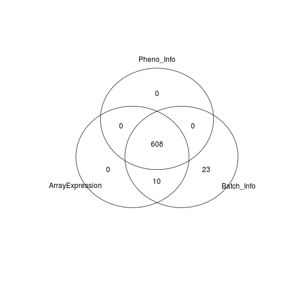

```r
# Venn of Sample.ID
ex <- eset_samples$sampleID
pp <- pheno_dat$Sample.ID
tt <- tech_pheno$Sample.ID
venninput <- list(ArrayExpression = ex, Batch_Info = tt, Pheno_Info = pp)
venn(venninput)
```

```r
dev.off()
```

## 3. check eset_samples, sample & batch info Sample.ID's match in names and numbers & merge all

```r
# 1. merge eset_samples with pheno_dat.  Keep ALL overlaps only
eset_pheno_merge <- merge(eset_samples, pheno_dat, by.x = "sampleID", by.y = "Sample.ID")
eset_pheno_merge <- eset_pheno_merge[order(eset_pheno_merge$chip_order), ]
dim(eset_samples)
```

```
## [1] 618   3
```

```r
dim(eset_pheno_merge)  # check size
```

```
## [1] 608  10
```

```r
# 2. merge eset_pheno_merge with tech_pheno
eset_pheno_batch_merge <- merge(eset_pheno_merge, tech_pheno, by.x = "sampleID",
    by.y = "Sample.ID")
eset_pheno_batch_merge <- eset_pheno_batch_merge[order(eset_pheno_batch_merge$chip_order),
    ]
dim(eset_samples)
```

```
## [1] 618   3
```

```r
dim(eset_pheno_merge)
```

```
## [1] 608  10
```

```r
dim(eset_pheno_batch_merge)  # check size
```

```
## [1] 608  26
```

```r
# 3. merge all with genomestudio final report
eset_pheno_batch_gs_merge <- merge(eset_pheno_batch_merge, gs_sample_data, by.x = "sampleID",
    by.y = "Sample.ID")
eset_pheno_batch_gs_merge <- eset_pheno_batch_gs_merge[order(eset_pheno_batch_gs_merge$chip_order),
    ]

# final look at numbers in each merged data set
dim(eset_samples)
```

```
## [1] 618   3
```

```r
dim(eset_pheno_merge)
```

```
## [1] 608  10
```

```r
dim(eset_pheno_batch_merge)
```

```
## [1] 608  26
```

```r
dim(eset_pheno_batch_gs_merge)
```

```
## [1] 608  45
```

```r
# names
names(eset_pheno_batch_gs_merge)
```

```
##  [1] "sampleID"
##  [2] "has_expression"
##  [3] "chip_order"
##  [4] "SEX"
##  [5] "GROUPS"
##  [6] "TISSUE"
##  [7] "PHENOTYPE"
##  [8] "Study_ID"
##  [9] "Study_ID_Count"
## [10] "GROUPS_ORIGINAL"
## [11] "tech.Sentrix.Barcode"
## [12] "tech.SampleSection"
## [13] "tech.Batch"
## [14] "tech.Date_out"
## [15] "tech.Date_extraction"
```

[output cut: 30 more lines]

## 4. Subset raw ExpressionSet to matched/complete Sample.IDs & Update pData() slot.

```r
# samples in gene expression data
samples_eset <- pData(eset_raw)$sampleID
length(samples_eset)
```

```
## [1] 618
```

```r
# samples with complete data
samples_complete_data <- eset_pheno_batch_gs_merge$sampleID
length(samples_complete_data)
```

```
## [1] 608
```

```r
# samples to remove
samples_to_remove <- (samples_eset %in% samples_complete_data) == FALSE
samples_to_remove <- pData(eset_raw)$sampleID[samples_to_remove]
length(samples_to_remove)
```

```
## [1] 10
```

```r
# rename eset_raw & save
eset_raw_preqc <- eset_raw
save(eset_raw_preqc, file = paste(out_dir, "/", project_name, ".eset_raw_preqc.RData",
    sep = ""))

# subset eset_raw
eset_raw <- removeSamples_eset_lumi(eset = eset_raw_preqc, sampleRemove = samples_to_remove)
```

```
## The sample names in the controlData don't match sampleNames(object).
```

```r
eset_raw
```

```
## Summary of data information:
##   Data File Information:
##      GSGX Version    1.9.0
##      Report Date 29/10/2013 14:56:38
##      Project BRC_GAP_Expression_02
##      Group Set   BRC_GAP_Expression
##      Analysis    BRC_GAP_Expression_nonorm_nobkgd
##      Normalization   none
##
## Major Operation History:
##             submitted            finished
## 1 2014-01-10 18:10:00 2014-01-10 18:15:27
## 2 2014-01-10 18:10:00 2014-01-10 18:15:27
##                                                                                                                    command
## 1 lumiR("/media/D/expression/GAP_Expression/final_reports_genomestudio/Sample_and_Control_Probe_Profile_FinalReport.txt",
## 2                                                       lib.mapping = "lumiHumanIDMapping", checkDupId = TRUE, QC = TRUE,
##   lumiVersion
## 1      2.14.1
## 2      2.14.1
## ...
##              submitted            finished
## 9  2014-01-10 18:19:38 2014-01-10 18:19:45
## 10 2014-01-10 18:20:28 2014-01-10 18:20:30
##                                                                        command
## 9  addNuID2lumi(x.lumi = x.lumi, lib.mapping = lib.mapping, verbose = verbose)
## 10                                                     Subsetting 618 samples.
##    lumiVersion
## 9       2.14.1
## 10      2.14.1
##
## Object Information:
## LumiBatch (storageMode: lockedEnvironment)
## assayData: 47231 features, 608 samples
##   element names: beadNum, detection, exprs, se.exprs
## protocolData: none
## phenoData
##   sampleNames: 9020374058_A 9020374058_B ... 9249907052_L (608
##     total)
##   varLabels: sampleID
##   varMetadata: labelDescription
## featureData
##   featureNames: Ku8QhfS0n_hIOABXuE fqPEquJRRlSVSfL.8A ...
##     N8t5EuJCr0Tk9.zHno (47231 total)
##   fvarLabels: ProbeID TargetID ... DEFINITION (17 total)
##   fvarMetadata: labelDescription
## experimentData: use 'experimentData(object)'
## Annotation: lumiHumanAll.db
## Control Data: Available
## QC information: Please run summary(x, 'QC') for details!
```

```r
# update pData
old_pdata <- pData(eset_raw)
old_pdata$old_order <- 1:dim(old_pdata)[1]

# merge with eset_pheno_batch_gs_merge
new_pdata <- merge(old_pdata, eset_pheno_batch_gs_merge, by.x = "sampleID",
    by.y = "sampleID", all = TRUE, sort = FALSE)
new_pdata <- new_pdata[order(new_pdata$old_order), ]

# remove columns old_order has_expression chip_order
new_pdata <- new_pdata[, -c(2, 3, 4)]

# update rownames
rownames(new_pdata) <- new_pdata$sampleID

# update pData slot
pData(eset_raw) <- new_pdata
dim(pData(eset_raw))
```

```
## [1] 608  43
```

```r
eset_raw  # varLabels: sampleID SEX ... Noise (43 total)
```

```
## Summary of data information:
##   Data File Information:
##      GSGX Version    1.9.0
##      Report Date 29/10/2013 14:56:38
##      Project BRC_GAP_Expression_02
##      Group Set   BRC_GAP_Expression
##      Analysis    BRC_GAP_Expression_nonorm_nobkgd
##      Normalization   none
##
## Major Operation History:
##             submitted            finished
## 1 2014-01-10 18:10:00 2014-01-10 18:15:27
## 2 2014-01-10 18:10:00 2014-01-10 18:15:27
##                                                                                                                    command
## 1 lumiR("/media/D/expression/GAP_Expression/final_reports_genomestudio/Sample_and_Control_Probe_Profile_FinalReport.txt",
## 2                                                       lib.mapping = "lumiHumanIDMapping", checkDupId = TRUE, QC = TRUE,
##   lumiVersion
## 1      2.14.1
## 2      2.14.1
## ...
##              submitted            finished
## 9  2014-01-10 18:19:38 2014-01-10 18:19:45
## 10 2014-01-10 18:20:28 2014-01-10 18:20:30
##                                                                        command
## 9  addNuID2lumi(x.lumi = x.lumi, lib.mapping = lib.mapping, verbose = verbose)
## 10                                                     Subsetting 618 samples.
##    lumiVersion
## 9       2.14.1
## 10      2.14.1
##
## Object Information:
## LumiBatch (storageMode: lockedEnvironment)
## assayData: 47231 features, 608 samples
##   element names: beadNum, detection, exprs, se.exprs
## protocolData: none
## phenoData
##   sampleNames: 9020374058_A 9020374058_B ... 9249907052_L (608
##     total)
##   varLabels: sampleID SEX ... Noise (43 total)
##   varMetadata: labelDescription
## featureData
##   featureNames: Ku8QhfS0n_hIOABXuE fqPEquJRRlSVSfL.8A ...
##     N8t5EuJCr0Tk9.zHno (47231 total)
##   fvarLabels: ProbeID TargetID ... DEFINITION (17 total)
##   fvarMetadata: labelDescription
## experimentData: use 'experimentData(object)'
## Annotation: lumiHumanAll.db
## Control Data: Available
## QC information: Please run summary(x, 'QC') for details!
```

## 5. Add nuID to fData

```r
# Add nuID to fData
fData(eset_raw)$nuID <- rownames(fData(eset_raw))
head(fData(eset_raw))
```

```
##                    ProbeID TargetID  TRANSCRIPT ILMN_GENE   REFSEQ_ID
## Ku8QhfS0n_hIOABXuE 6450255      7A5 ILMN_183371       7A5 NM_182762.2
## fqPEquJRRlSVSfL.8A 2570615     A1BG ILMN_175569      A1BG NM_130786.2
## ckiehnugOno9d7vf1Q 6370619     A1BG  ILMN_18893      A1BG NM_130786.2
## x57Vw5B5Fbt5JUnQkI 2600039     A1CF  ILMN_18532      A1CF NM_138932.1
## ritxUH.kuHlYqjozpE 2650615     A1CF   ILMN_7300      A1CF NM_014576.2
## QpE5UiUgmJOJEkPXpc 5340672     A1CF ILMN_165661      A1CF NM_138933.1
##                    UNIGENE_ID ENTREZ_GENE_ID   ACCESSION SYMBOL
## Ku8QhfS0n_hIOABXuE                    346389 NM_182762.2    7A5
## fqPEquJRRlSVSfL.8A                         1 NM_130786.2   A1BG
## ckiehnugOno9d7vf1Q                         1 NM_130786.2   A1BG
## x57Vw5B5Fbt5JUnQkI                     29974 NM_138932.1   A1CF
## ritxUH.kuHlYqjozpE                     29974 NM_014576.2   A1CF
## QpE5UiUgmJOJEkPXpc                     29974 NM_138933.1   A1CF
##                    PROTEIN_PRODUCT     PROBE_ID PROBE_TYPE PROBE_START
## Ku8QhfS0n_hIOABXuE     NP_877439.2 ILMN_1762337          S        2725
## fqPEquJRRlSVSfL.8A     NP_570602.2 ILMN_2055271          S        3151
## ckiehnugOno9d7vf1Q     NP_570602.2 ILMN_1736007          S        2512
## x57Vw5B5Fbt5JUnQkI     NP_620310.1 ILMN_2383229          A        1826
## ritxUH.kuHlYqjozpE     NP_055391.2 ILMN_1806310          A        1893
## QpE5UiUgmJOJEkPXpc     NP_620311.1 ILMN_1779670          I         278
##                    CHROMOSOME PROBE_CHR_ORIENTATION PROBE_COORDINATES
## Ku8QhfS0n_hIOABXuE          7                     - 20147187-20147236
## fqPEquJRRlSVSfL.8A         19                     - 63548541-63548590
## ckiehnugOno9d7vf1Q         19                     - 63549180-63549229
## x57Vw5B5Fbt5JUnQkI         10                     - 52566586-52566635
## ritxUH.kuHlYqjozpE         10                     - 52566495-52566544
## QpE5UiUgmJOJEkPXpc         10                     - 52610479-52610528
##                                                                                         DEFINITION
## Ku8QhfS0n_hIOABXuE                          Homo sapiens putative binding protein 7a5 (7A5), mRNA.
## fqPEquJRRlSVSfL.8A                               Homo sapiens alpha-1-B glycoprotein (A1BG), mRNA.
## ckiehnugOno9d7vf1Q                               Homo sapiens alpha-1-B glycoprotein (A1BG), mRNA.
## x57Vw5B5Fbt5JUnQkI Homo sapiens APOBEC1 complementation factor (A1CF), transcript variant 2, mRNA.
## ritxUH.kuHlYqjozpE Homo sapiens APOBEC1 complementation factor (A1CF), transcript variant 1, mRNA.
## QpE5UiUgmJOJEkPXpc Homo sapiens APOBEC1 complementation factor (A1CF), transcript variant 3, mRNA.
##                                  nuID
## Ku8QhfS0n_hIOABXuE Ku8QhfS0n_hIOABXuE
## fqPEquJRRlSVSfL.8A fqPEquJRRlSVSfL.8A
## ckiehnugOno9d7vf1Q ckiehnugOno9d7vf1Q
## x57Vw5B5Fbt5JUnQkI x57Vw5B5Fbt5JUnQkI
## ritxUH.kuHlYqjozpE ritxUH.kuHlYqjozpE
## QpE5UiUgmJOJEkPXpc QpE5UiUgmJOJEkPXpc
```

## 6. Save updated raw ExpressionSet eset_raw

```r
# Save updated raw ExpressionSet eset_raw
save(eset_raw, file = paste(out_dir, "/", project_name, ".eset_raw.RData", sep = ""))
```

## 7. Write data files to out_dir for eset_raw

```r
# Write data files to out_dir for eset_raw
write_expression_files(eset = eset_raw, outfile = paste(out_dir, "/", project_name,
    ".eset_raw", sep = ""))
```

```
##  Writing probe exprs matrix [ /media/D/expression/GAP_Expression/GAPtest01_lumi_processing/GAPtest01.eset_raw.exprs_matrix.txt ]

##  Writing probe se.exprs matrix [ /media/D/expression/GAP_Expression/GAPtest01_lumi_processing/GAPtest01.eset_raw.se.exprs_matrix.txt ]

##  Writing probe detection matrix [ /media/D/expression/GAP_Expression/GAPtest01_lumi_processing/GAPtest01.eset_raw.detection_matrix.txt ]

##  Writing probe beadNum matrix [ /media/D/expression/GAP_Expression/GAPtest01_lumi_processing/GAPtest01.eset_raw.beadNum_matrix.txt ]

##  Writing probe PCA matrix [ /media/D/expression/GAP_Expression/GAPtest01_lumi_processing/GAPtest01.eset_raw.pca_matrix.txt ]

##  Writing pData slot of eset and adding PCA data to [ /media/D/expression/GAP_Expression/GAPtest01_lumi_processing/GAPtest01.eset_raw.pData.txt ]

##  Writing fData slot of eset [ /media/D/expression/GAP_Expression/GAPtest01_lumi_processing/GAPtest01.eset_raw.fData.txt ]
```

## 8. Basic QC and plots on eset_raw

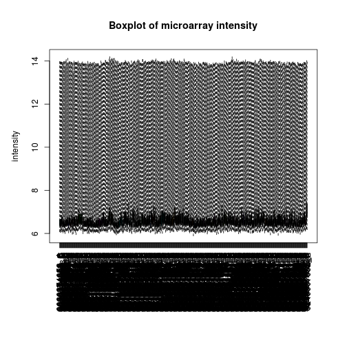

```r
# Basic Plots
chip_col <- labels2colors(as.character(pData(eset_raw)$Sentrix.Barcode))
plot(eset_raw, what = "boxplot", col = chip_col)
```

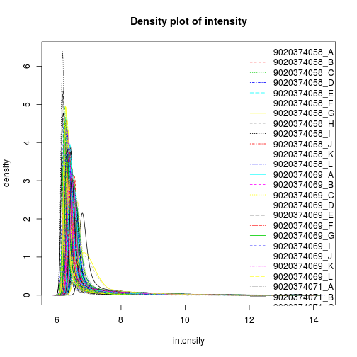

```r
plot(eset_raw, what = "density")
```

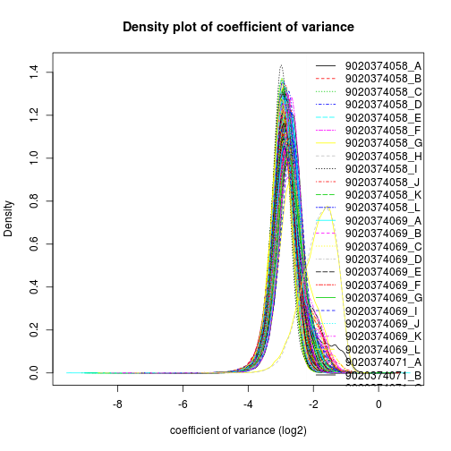

```r
plot(eset_raw, what = "cv")
```

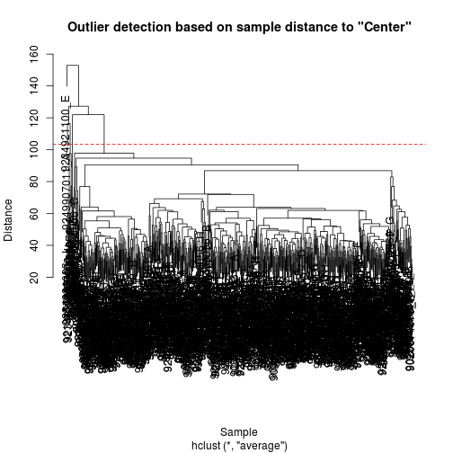

```r
plot(eset_raw, what = "outlier")
```

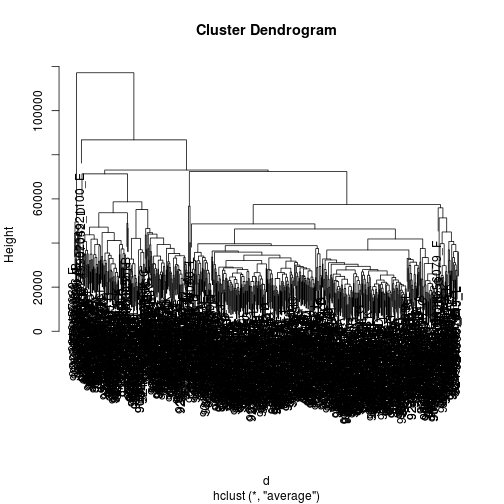

```r
# flashClust
datExprs <- exprs(eset_raw)
dist_exprs <- dist(t(datExprs), method = "e")
sampleTree <- flashClust(dist_exprs, method = "average")
plot(sampleTree)
```

## 9. SampleNetwork on all samples as a first pass

```r
# SampleNetwork on all samples as a first pass
samle_names <- sampleNames(eset)
```

```
## Error: error in evaluating the argument 'object' in selecting a method for function 'sampleNames': Error: object 'eset' not found
```

```r
IAC = cor(datExprs, method = "p", use = "p")
diag(IAC) = 0
A.IAC = ((1 + IAC)/2)^2  ## ADJACENCY MATRIX
FNC = fundamentalNetworkConcepts(A.IAC)  ## WGCNA
K2 = FNC$ScaledConnectivity
Z.K = (K2 - mean(K2))/sd(K2)
Z.C = (FNC$ClusterCoef - mean(FNC$ClusterCoef))/sd(FNC$ClusterCoef)
Z.MAR = (FNC$MAR - mean(FNC$MAR))/sd(FNC$MAR)
rho <- signif(cor.test(Z.K, Z.C, method = "s")$estimate, 2)
rho_pvalue <- signif(cor.test(Z.K, Z.C, method = "s")$p.value, 2)
colorvec <- colorvec <- labels2colors(as.character(pData(eset)$Sentrix.Barcode))
```

```
## Error: error in evaluating the argument 'object' in selecting a method for function 'pData': Error: object 'eset' not found
```

```r
## OUTLIERS
Z.K_outliers <- Z.K < -sd_thrs
```

```
## Error: object 'sd_thrs' not found
```

```r
Z.K_outliers <- names(Z.K_outliers[Z.K_outliers == TRUE])
```

```
## Error: object 'Z.K_outliers' not found
```

```r
n_outliers <- length(Z.K_outliers)
```

```
## Error: object 'Z.K_outliers' not found
```

```r
mean_IAC <- mean(IAC[upper.tri(IAC)])
min_Z.K <- min(Z.K)
cat(" Number of Z.K outliers [", n_outliers, "]", "\r", "\n")
```

```
## Error: object 'n_outliers' not found
```

```r
cat(" mean_IAC [", mean_IAC, "]", "\r", "\n")
```

```
##  mean_IAC [ 0.9296 ]
```

```r
#
local({
    colLab <<- function(n, treeorder) {
        if (is.leaf(n)) {
            a <- attributes(n)
            i <<- i + 1
            attr(n, "nodePar") <- c(a$nodePar, list(lab.col = colorvec[treeorder][i],
                lab.font = i%%3))
        }
        n
    }
    i <- 0
})
## Cluster for pics
meanIAC <- mean(IAC[upper.tri(IAC)], na.rm = T)
cluster1 <- hclust(as.dist(1 - A.IAC), method = "average")
cluster1order <- cluster1$order
cluster2 <- as.dendrogram(cluster1, hang = 0.1)
cluster3 <- dendrapply(cluster2, colLab, cluster1order)
```

```
## Error: object 'colorvec' not found
```

```r
## PLOTS cluster IAC
par(mfrow = c(2, 2))
par(mar = c(5, 6, 4, 2))
plot(cluster3, nodePar = list(lab.cex = 1, pch = NA), main = paste("Mean ISA = ",
    signif(mean(A.IAC[upper.tri(A.IAC)]), 3), sep = ""), xlab = "", ylab = "1 - ISA",
    sub = "", cex.main = 1.8, cex.lab = 1.4)
```

```
## Error: error in evaluating the argument 'x' in selecting a method for function 'plot': Error: object 'cluster3' not found
```

```r
mtext(paste("distance: 1 - ISA ", sep = ""), cex = 0.8, line = 0.2)
```

```
## Error: plot.new has not been called yet
```

```r
## Connectivity
par(mar = c(5, 5, 4, 2))
plot(Z.K, main = "Connectivity", ylab = "Z.K", xaxt = "n", xlab = "Sample",
    type = "n", cex.main = 1.8, cex.lab = 1.4)
text(Z.K, labels = samle_names, cex = 0.8, col = colorvec)
```

```
## Error: object 'samle_names' not found
```

```r
abline(h = -2)
abline(h = -3)
## ClusterCoef
par(mar = c(5, 5, 4, 2))
plot(Z.C, main = "ClusterCoef", ylab = "Z.C", xaxt = "n", xlab = "Sample", cex.main = 1.8,
    cex.lab = 1.4, type = "n")
text(Z.C, labels = samle_names, cex = 0.8, col = colorvec)
```

```
## Error: object 'samle_names' not found
```

```r
abline(h = -2)
abline(h = -3)
## Connectivity vs ClusterCoef
par(mar = c(5, 5, 4, 2))
plot(Z.K, Z.C, main = "Connectivity vs ClusterCoef", xlab = "Z.K", ylab = "Z.C",
    col = colorvec, cex.main = 1.8, cex.lab = 1.4)
```

```
## Error: object 'colorvec' not found
```

```r
abline(lm(Z.C ~ Z.K), col = "black", lwd = 2)
mtext(paste("rho = ", signif(cor.test(Z.K, Z.C, method = "s")$estimate, 2),
    " p = ", signif(cor.test(Z.K, Z.C, method = "s")$p.value, 2), sep = ""),
    cex = 0.8, line = 0.2)
abline(v = -2, lty = 2, col = "grey")
abline(h = -2, lty = 2, col = "grey")
#
dev.off()
```

## 10. Some more advanced QC plots & PCA with Batch variables

```r
# Some more advanced QC plots & PCA with Batch variables PCA Plots, heatmaps
# and SampleNetwork Z.K plots Review these manually
gx_qc_plots_lumi(eset = eset_raw, outfile = paste(out_dir, "/", project_name,
    ".eset_raw", sep = ""))
```

```
##  startin qc plots

##  saving all plots to  /media/D/expression/GAP_Expression/GAPtest01_lumi_processing/GAPtest01.eset_raw.qc_plots.pdf
```

## MBCB (Model-based Background Correction for Beadarray)

## 1. Run mbcb.correct(signal,negCon,npBool=FALSE,mleBool=TRUE,isRawBead=FALSE)

```r
# Run Model-based Background Correction for Beadarray : method = MLE
# mbcb.correct(signal,negCon,npBool=FALSE,mleBool=TRUE, isRawBead=FALSE)
eset_bg <- bgcor_mbcb(eset = eset_raw, outfile = paste(out_dir, "/", project_name,
    ".eset_bg", sep = ""))
```

```
##  Start background correction

##  get negativeControl bead data

##  get expression bead data

##  set data for mbcb

##  run background correct using mbcb.correct(method="MLE")
```

```
## 1 / 608  complete.
## 2 / 608  complete.
## 3 / 608  complete.
## 4 / 608  complete.
## 5 / 608  complete.
## 6 / 608  complete.
## 7 / 608  complete.
## 8 / 608  complete.
## 9 / 608  complete.
## 10 / 608  complete.
## 11 / 608  complete.
## 12 / 608  complete.
## 13 / 608  complete.
## 14 / 608  complete.
## 15 / 608  complete.
```

[output cut: 593 more lines]

```
##  mbcb complete

##  saveing raw mbcb matrix to  /media/D/expression/GAP_Expression/GAPtest01_lumi_processing/GAPtest01.eset_bg.mbcb.correct.output.RData

##  Selected mbcb method:  MLE

##  replace names with original sampleNames(eset_raw), as R adds X to numbers

##  Creating Background Corrected Data set: eset_bg

##  replace old exprs data with new mbcb Background corrected data

##  returning new mbcb Background corrected data: eset_bg
```

```r
eset_bg
```

```
## Summary of data information:
##   Data File Information:
##      GSGX Version    1.9.0
##      Report Date 29/10/2013 14:56:38
##      Project BRC_GAP_Expression_02
##      Group Set   BRC_GAP_Expression
##      Analysis    BRC_GAP_Expression_nonorm_nobkgd
##      Normalization   none
##
## Major Operation History:
##             submitted            finished
## 1 2014-01-10 18:10:00 2014-01-10 18:15:27
## 2 2014-01-10 18:10:00 2014-01-10 18:15:27
##                                                                                                                    command
## 1 lumiR("/media/D/expression/GAP_Expression/final_reports_genomestudio/Sample_and_Control_Probe_Profile_FinalReport.txt",
## 2                                                       lib.mapping = "lumiHumanIDMapping", checkDupId = TRUE, QC = TRUE,
##   lumiVersion
## 1      2.14.1
## 2      2.14.1
## ...
##              submitted            finished
## 9  2014-01-10 18:19:38 2014-01-10 18:19:45
## 10 2014-01-10 18:20:28 2014-01-10 18:20:30
##                                                                        command
## 9  addNuID2lumi(x.lumi = x.lumi, lib.mapping = lib.mapping, verbose = verbose)
## 10                                                     Subsetting 618 samples.
##    lumiVersion
## 9       2.14.1
## 10      2.14.1
##
## Object Information:
## LumiBatch (storageMode: lockedEnvironment)
## assayData: 47231 features, 608 samples
##   element names: beadNum, detection, exprs, se.exprs
## protocolData: none
## phenoData
##   sampleNames: 9020374058_A 9020374058_B ... 9249907052_L (608
##     total)
##   varLabels: sampleID SEX ... Noise (43 total)
##   varMetadata: labelDescription
## featureData
##   featureNames: Ku8QhfS0n_hIOABXuE fqPEquJRRlSVSfL.8A ...
##     N8t5EuJCr0Tk9.zHno (47231 total)
##   fvarLabels: ProbeID TargetID ... nuID (18 total)
##   fvarMetadata: labelDescription
## experimentData: use 'experimentData(object)'
## Annotation: lumiHumanAll.db
## Control Data: Available
## QC information: Please run summary(x, 'QC') for details!
```

## 2. SAVE BACKGROUND CORRECTED DATA

```r
save(eset_bg, file = paste(out_dir, "/", project_name, ".eset_bg.RData", sep = ""),
    compress = T)
```

## 3. Write data files to out_dir for eset_bg

```r
# Write data files to out_dir for eset_raw
write_expression_files(eset = eset_bg, outfile = paste(out_dir, "/", project_name,
    ".eset_bg", sep = ""))
```

```
##  Writing probe exprs matrix [ /media/D/expression/GAP_Expression/GAPtest01_lumi_processing/GAPtest01.eset_bg.exprs_matrix.txt ]

##  Writing probe se.exprs matrix [ /media/D/expression/GAP_Expression/GAPtest01_lumi_processing/GAPtest01.eset_bg.se.exprs_matrix.txt ]

##  Writing probe detection matrix [ /media/D/expression/GAP_Expression/GAPtest01_lumi_processing/GAPtest01.eset_bg.detection_matrix.txt ]

##  Writing probe beadNum matrix [ /media/D/expression/GAP_Expression/GAPtest01_lumi_processing/GAPtest01.eset_bg.beadNum_matrix.txt ]

##  Writing probe PCA matrix [ /media/D/expression/GAP_Expression/GAPtest01_lumi_processing/GAPtest01.eset_bg.pca_matrix.txt ]

##  Writing pData slot of eset and adding PCA data to [ /media/D/expression/GAP_Expression/GAPtest01_lumi_processing/GAPtest01.eset_bg.pData.txt ]

##  Writing fData slot of eset [ /media/D/expression/GAP_Expression/GAPtest01_lumi_processing/GAPtest01.eset_bg.fData.txt ]
```

```r
# NB: SKIP QC PLOTS ETC. Not really needed at this point
```

## Id Detected Probes per GROUPS

```r
## PROBE DETECTED 2SD ABOVE MEAN BACKGROUND ##
cat(" Calculating Probe Detection rates. \n Probe is seen as Detected if it has background corrected signal intensity >= 2SD of the mean intensity of the negative control beads",
    "\r", "\n")
## get expression matrix
gx <- exprs(eset_bg)
## get negative bead ranges mean or max or >2SD mean of neg beads
neg_2sd <- neg_mean + 2 * neg_sd
## sweep through gx matrix to id probes > 2SD Mean of negative beads
det <- sweep(gx, 1, neg_2sd, ">=")
## Writing Probe Detection Calls to file #
det_tmp <- as.data.frame(det)
det_tmp$nuID <- rownames(det_tmp)
probe_detected <- merge(fData(eset_bg), det_tmp, by.x = "nuID", by.y = "nuID",
    sort = FALSE)
cat(" Writing Probe Detection Calls to", paste(out_dir, "/", project_name, ".eset_bg.probe_detected.txt",
    sep = ""), "\r", "\n")
write.table(probe_detected, file = paste(out_dir, "/", project_name, ".eset_bg.probe_detected.txt",
    sep = ""), sep = "\t", row.names = FALSE, quote = FALSE)
rm("det_tmp")
## probe_detection counts
probe_detection <- rowSums(det)
## n samples
n_samples <- dim(gx)[2]
## probe annotations
probes_not_detected_in_any_sample <- probe_detection == 0
probes_detected_in_80_sample <- probe_detection >= n_samples * 0.8
probes_detected_in_all_sample <- probe_detection == n_samples
probe_annotations_0_detected <- fData(eset_bg[probes_not_detected_in_any_sample,
    ])
probe_annotations_80_detected <- fData(eset_bg[probes_detected_in_80_sample,
    ])
probe_annotations_100_detected <- fData(eset_bg[probes_detected_in_all_sample,
    ])
cat(" Adding detetion call rate for all probes and samples to fData() slot for eset_bg",
    "\r", "\n")
fData(eset_bg)$n_detected <- probe_detection
fData(eset_bg)$n_detected_call_rate <- round(probe_detection/n_samples, 3)
## sample_detection counts
n_probes <- dim(eset_bg)[1]
sample_detection <- colSums(det)
pData(eset_bg)$n_probes_detected <- sample_detection
pData(eset_bg)$n_probes_detected_call_rate <- round(sample_detection/n_probes,
    3)
save(eset_bg, file = paste(out_dir, "/", project_name, ".eset_bg.RData", sep = ""))
## get group information from pData() slot
group_names <- unique(pData(eset_bg)$GROUPS)
groups <- pData(eset_bg)$GROUPS
n_groups <- length(group_names)
## get expression matrix ##
gx <- exprs(eset_bg)
neg_2sd <- as.numeric(neg_2sd)

## loop through each group and id probes > 2SD mean neg beads in X% of
## samples/group
for (n in group_names) {
    cat(" Finding probes in ", probe_det, " of sample group [", n, "] with signal intensity >= 2SD mean intensity of the negative control beads ",
        "\r", "\n")
    group_label <- paste(n)
    sel_samples <- pData(eset_bg)$GROUPS == n
    n_samples_in_group <- dim(gx[, sel_samples])[2]
    cat(" Number of samples in group [", n, "] = ", n_samples_in_group, "\r",
        "\n")
    detection_matrix <- sweep(gx[, sel_samples], 1, neg_2sd[sel_samples], ">=")
    group_probe_detection <- rowSums(detection_matrix) >= (probe_det/100) *
        n_samples_in_group
    group_probe_detection_nuID <- rownames(gx[group_probe_detection == TRUE,
        ])
    cat(" Number of probes in group [", n, "] with signal intensity >= 2SD mean intensity of the negative control beads = ",
        length(group_probe_detection_nuID), "\r", "\n")
    cat(" Writing probe list to ", paste(out_dir, "/", project_name, ".GROUP.",
        group_label, ".detected_probes_nuID.txt", sep = ""), "\r", "\n")
    det_probes <- as.data.frame(group_probe_detection_nuID)
    colnames(det_probes) <- c("nuID")
    write.table(det_probes, file = paste(out_dir, "/", project_name, ".GROUP.",
        group_label, ".detected_probes_nuID.txt", sep = ""), row.names = FALSE,
        quote = FALSE, col.names = FALSE)
}

## Y CHROM EXPRESSION IN XIST MALES
cat(" Y Chromosome probe detection based on XIST males", "\r", "\n")
xist_males <- pData(eset_bg)$xist_gender == "Male"
gx_y <- exprs(eset_bg[fData(eset_bg)$CHR == "Y", ])
detection_matrix_y <- sweep(gx_y[, xist_males], 1, neg_2sd[xist_males], ">=")
y_probe_detection <- rowSums(detection_matrix_y) >= probe_det * sum(xist_males ==
    TRUE)
y_probe_detection_nuID <- rownames(gx_y[y_probe_detection, ])
y_det_probes <- as.data.frame(y_probe_detection_nuID)
colnames(y_det_probes) <- c("nuID")
write.table(y_det_probes, file = paste(out_dir, "/", project_name, ".GROUP.Y.detected_probes_nuID.txt",
    sep = ""), row.names = FALSE, quote = FALSE, col.names = FALSE)

## writing final good probe list
cat(" writing final good probe list to ", paste(out_dir, "/", project_name,
    ".detected_probes_nuID_final.txt", sep = ""), "\r", "\n")
system(paste("cat ", out_dir, "/", project_name, "****.detected_probes_nuID.txt | sort | uniq >> ",
    out_dir, "/", project_name, ".detected_probes_nuID_final.txt", sep = ""))
good_probes <- read.table(file = paste(out_dir, "/", project_name, ".detected_probes_nuID_final.txt",
    sep = ""), head = FALSE)
good_probes <- paste(good_probes[, 1])
n_good_probes <- length(good_probes)
cat(" Total number of good probes = ", n_good_probes, "\n", "\r")
good_probes_annotation <- fData(eset_bg[paste(good_probes, sep = ""), ])
good_probes_annotation$raw_mean <- apply(exprs(eset_bg[good_probes, ]), 1, mean)
good_probes_annotation$raw_sd <- apply(exprs(eset_bg[good_probes, ]), 1, sd)
good_probes_annotation$raw_var <- apply(exprs(eset_bg[good_probes, ]), 1, var)
good_probes_annotation$raw_min <- apply(exprs(eset_bg[good_probes, ]), 1, min)
good_probes_annotation$raw_max <- apply(exprs(eset_bg[good_probes, ]), 1, max)
head(good_probes_annotation)
cat(" saving good probe annotations to ", paste(out_dir, "/", project_name,
    ".detected_probes_nuID_final.***", sep = ""), "\r", "\n")
save(good_probes_annotation, file = paste(out_dir, "/", project_name, ".detected_probes_nuID_final.RData",
    sep = ""))
write.table(good_probes_annotation, file = paste(out_dir, "/", project_name,
    ".detected_probes_nuID_final.txt", sep = ""), quote = F, sep = "\t", row.names = F)
```

## Check Gender based on XIST gene expression

```r
cat(" Checking Gender based on XIST gene expression", "\r", "\n")
```

```
##  Checking Gender based on XIST gene expression
```

```r
## get neg control data from eset_bg
negativeControl <- getControlData(eset_bg)
negativeControl <- subset(negativeControl, negativeControl$controlType == "NEGATIVE")
negativeControl <- negativeControl[, c(3:dim(negativeControl)[2])]
## get neg control info mean,sd,max etc
neg_max <- apply(negativeControl, 2, max)
neg_sd <- apply(negativeControl, 2, sd)
neg_mean <- apply(negativeControl, 2, mean)
neg_2sd <- neg_mean + 2 * neg_sd
## get XIST gene postion
xist_raw <- fData(eset_raw)$ILMN_GENE == "XIST"
xist_bkcor <- fData(eset_bg)$ILMN_GENE == "XIST"
## get XIST gene expression signal
xist_gx_raw <- exprs(eset_raw[xist_raw, ])
xist_gx_raw <- as.data.frame(t(xist_gx_raw))
xist_gx_bkcor <- exprs(eset_bg[xist_bkcor, ])
xist_gx_bkcor <- as.data.frame(t(xist_gx_bkcor))
## cobine raw and bkCro gx data
xist_gx <- cbind(xist_gx_raw, xist_gx_bkcor)
colnames(xist_gx) <- c("raw_XIST", "bkcor_XIST")
xist_gx$neg_2sd <- neg_2sd
xist_gx$neg_max <- neg_max
xist_gx$neg_mean <- neg_mean
xist_gx$neg_sd <- neg_sd
## gender based on XIST expression 1=female , 0 = male
xist_gx$XIST_Gender_max <- ifelse(xist_gx$bkcor_XIST > xist_gx$neg_max, 1, 0)
xist_gx$XIST_Gender_2sd <- ifelse(xist_gx$bkcor_XIST > xist_gx$neg_2sd, 1, 0)  # THIS WORKS!! IF GENE IS > 2SD_NEG_BEAD THEN ITS EXPRESSED/DETECTED!
xist_gx$XIST_z <- (xist_gx$bkcor_XIST - xist_gx$neg_mean)/xist_gx$neg_sd
xist_gx$Sample.ID <- rownames(xist_gx)
# illumina detection p value for xist
xist_gx$xist_illumina_detection_p <- as.numeric(detection(eset_bg[fData(eset_bg)$ILMN_GENE ==
    "XIST", ]))
xist_gx$xist_illumina_detection_p <- ifelse(xist_gx$xist_illumina_detection_p ==
    0, 1e-05, xist_gx$xist_illumina_detection_p)
# gender based on bg cor expression > 2SD negatibe beads
xist_gx$xist_gender <- ifelse(xist_gx$bkcor_XIST > xist_gx$neg_2sd, "Female",
    "Male")
# gender provided in database
xist_gx$clinical_gender <- pData(eset_bg)$SEX
# gender based on illumina detecetion p value
xist_gx$xist_illumina_detection_p_gender <- ifelse(xist_gx$xist_illumina_detection_p <=
    0.01, "Female", "Male")  ## 0.05 makes them all female!
# flag gender missmatch
xist_gx$gender_missmatch <- ifelse(xist_gx$xist_gender == xist_gx$clinical_gender,
    "PASS", "GENDER_MISSMATCH")
xist_gx$gender_missmatch_illumina_detection_p <- ifelse(xist_gx$xist_illumina_detection_p_gender ==
    xist_gx$clinical_gender, "PASS", "GENDER_MISSMATCH")
# head
head(xist_gx)
```

```
##              raw_XIST bkcor_XIST neg_2sd neg_max neg_mean neg_sd
## 9020374058_A    108.2      32.72  119.19   367.1    85.51 16.840
## 9020374058_B    105.8      30.18   97.51   186.4    83.64  6.935
## 9020374058_C    196.0     123.22   93.32   167.6    79.50  6.913
## 9020374058_D    114.3      38.18  102.94   212.7    85.04  8.949
## 9020374058_E     96.0      21.58   94.02   159.9    81.83  6.094
## 9020374058_F    109.9      31.32  101.60   164.4    87.96  6.824
##              XIST_Gender_max XIST_Gender_2sd XIST_z    Sample.ID
## 9020374058_A               0               0 -3.135 9020374058_A
## 9020374058_B               0               0 -7.709 9020374058_B
## 9020374058_C               0               1  6.325 9020374058_C
## 9020374058_D               0               0 -5.236 9020374058_D
## 9020374058_E               0               0 -9.887 9020374058_E
## 9020374058_F               0               0 -8.300 9020374058_F
##              xist_illumina_detection_p xist_gender clinical_gender
## 9020374058_A                   0.01429        Male            Male
## 9020374058_B                   0.00779        Male         Unknown
## 9020374058_C                   0.00001      Female          Female
## 9020374058_D                   0.00779        Male            Male
## 9020374058_E                   0.01169        Male            Male
## 9020374058_F                   0.00909        Male            Male
##              xist_illumina_detection_p_gender gender_missmatch
## 9020374058_A                             Male             PASS
## 9020374058_B                           Female GENDER_MISSMATCH
## 9020374058_C                           Female             PASS
## 9020374058_D                           Female             PASS
## 9020374058_E                             Male             PASS
## 9020374058_F                           Female             PASS
##              gender_missmatch_illumina_detection_p
## 9020374058_A                                  PASS
## 9020374058_B                      GENDER_MISSMATCH
## 9020374058_C                                  PASS
## 9020374058_D                      GENDER_MISSMATCH
## 9020374058_E                                  PASS
## 9020374058_F                      GENDER_MISSMATCH
```

```r
# table SEX
table(xist_gx$clinical_gender)
```

```
##
##  Female    Male Unknown
##     196     319      93
```

```r
table(xist_gx$xist_gender)
```

```
##
## Female   Male
##    228    380
```

```r
table(xist_gx$xist_illumina_detection_p_gender)
```

```
##
## Female   Male
##    546     62
```

```r
# tables SEX compare
table(xist_gx$xist_gender, xist_gx$clinical_gender)
```

```
##
##          Female Male Unknown
##   Female    180    4      44
##   Male       16  315      49
```

```r
table(xist_gx$xist_illumina_detection_p_gender, xist_gx$clinical_gender)
```

```
##
##          Female Male Unknown
##   Female    194  265      87
##   Male        2   54       6
```

```r
# Density plots with semi-transparent fill of SEX CALLS
df <- xist_gx[, c("bkcor_XIST", "clinical_gender", "xist_gender", "xist_illumina_detection_p_gender")]
head(df)
```

```
##              bkcor_XIST clinical_gender xist_gender
## 9020374058_A      32.72            Male        Male
## 9020374058_B      30.18         Unknown        Male
## 9020374058_C     123.22          Female      Female
## 9020374058_D      38.18            Male        Male
## 9020374058_E      21.58            Male        Male
## 9020374058_F      31.32            Male        Male
##              xist_illumina_detection_p_gender
## 9020374058_A                             Male
## 9020374058_B                           Female
## 9020374058_C                           Female
## 9020374058_D                           Female
## 9020374058_E                             Male
## 9020374058_F                           Female
```

```r
# Find the mean of each group library(plyr)
cdf_clinical_gender <- ddply(df, "clinical_gender", summarise, mean = mean(log2(bkcor_XIST)))
cdf_xist_gender <- ddply(df, "xist_gender", summarise, mean = mean(log2(bkcor_XIST)))
cdf_xist_illumina_detection_p_gender <- ddply(df, "xist_illumina_detection_p_gender",
    summarise, mean = mean(log2(bkcor_XIST)))
cdf_clinical_gender
```

```
##   clinical_gender  mean
## 1          Female 8.224
## 2            Male 5.168
## 3         Unknown 6.483
```

```r
cdf_xist_gender
```

```
##   xist_gender  mean
## 1      Female 8.347
## 2        Male 5.158
```

```r
cdf_xist_illumina_detection_p_gender
```

```
##   xist_illumina_detection_p_gender  mean
## 1                           Female 6.554
## 2                             Male 4.593
```

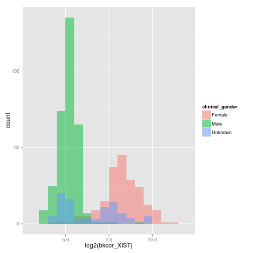

```r
# ggplots
ggplot(df, aes(x = log2(bkcor_XIST), fill = clinical_gender)) + geom_histogram(binwidth = 0.5,
    alpha = 0.5, position = "identity")
```

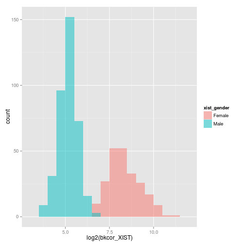

```r
ggplot(df, aes(x = log2(bkcor_XIST), fill = xist_gender)) + geom_histogram(binwidth = 0.5,
    alpha = 0.5, position = "identity")
```

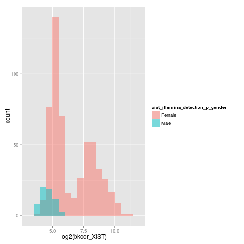

```r
ggplot(df, aes(x = log2(bkcor_XIST), fill = xist_illumina_detection_p_gender)) +
    geom_histogram(binwidth = 0.5, alpha = 0.5, position = "identity")
```

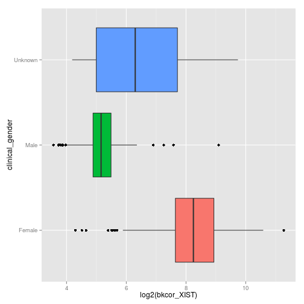

```r
# Box plots With flipped axes
ggplot(df, aes(y = log2(bkcor_XIST), x = clinical_gender, fill = clinical_gender)) +
    geom_boxplot() + guides(fill = FALSE) + coord_flip()
```

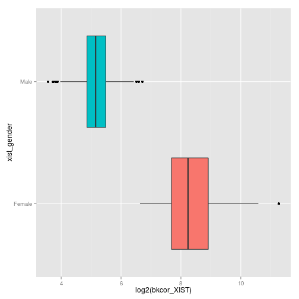

```r
ggplot(df, aes(y = log2(bkcor_XIST), x = xist_gender, fill = xist_gender)) +
    geom_boxplot() + guides(fill = FALSE) + coord_flip()
```

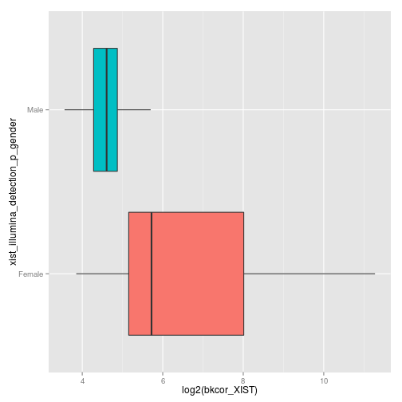

```r
ggplot(df, aes(y = log2(bkcor_XIST), x = xist_illumina_detection_p_gender, fill = xist_illumina_detection_p_gender)) +
    geom_boxplot() + guides(fill = FALSE) + coord_flip()
```

```r
# save plots to pdf
pdf(file = paste(out_dir, "/", project_name, ".eset_bg.XIST.Gender_plot.pdf",
    sep = ""), height = 8, width = 11)
# some plots
boxplot(log2(bkcor_XIST) ~ clinical_gender, data = xist_gx, main = "bg XIST.gx ~ clinical_gender")
boxplot(log2(bkcor_XIST) ~ xist_gender, data = xist_gx, main = "bg XIST.gx ~ xist_gender")
boxplot(log2(bkcor_XIST) ~ xist_illumina_detection_p_gender, data = xist_gx,
    main = "bg XIST.gx ~ xist_illumina_detection_p_gende")
plot(log2(xist_gx$bkcor_XIST), type = "p", col = 2 + xist_gx$XIST_Gender_2sd,
    pch = 19, cex = 0.6)
points(log2(xist_gx$neg_2sd), col = "blue", type = "l")
plot(xist_gx$bkcor_XIST, type = "p", col = 2 + xist_gx$XIST_Gender_2sd, pch = 19,
    cex = 0.6)
points(xist_gx$neg_2sd, col = "blue", type = "l")
dev.off()
```

```r
# save xist_gx data
save(xist_gx, file = paste(out_dir, "/", project_name, ".eset_bg.XIST.Gender.RData",
    sep = ""))
write.table(xist_gx, file = paste(out_dir, "/", project_name, ".eset_bg.XIST.Gender.txt",
    sep = ""), sep = "\t", row.names = F)
## check sex and add to pData

pheno_update <- merge(pData(eset_bg), xist_gx, by.x = "sampleID", by.y = "Sample.ID",
    all.x = TRUE, sort = FALSE)
rownames(pheno_update) <- pheno_update$sampleID
pData(eset_bg) <- pheno_update
save(eset_bg, file = paste(out_dir, "/", project_name, ".eset_bg.RData", sep = ""))
# n_gender_fails
n_gender_fails <- sum(pData(eset_bg)$gender_missmatch == "GENDER_MISSMATCH")
if (n_gender_fails > 0) {
    cat(" WARNING: Youn have GENDER_MISSMATCH samples!!!!!!! N=[", n_gender_fails,
        "]", "\r", "\n")
} else {
    cat(" Congratulations! \n All your Males are Male and Females are Female. \n You have NO GENDER_MISSMATCH samples!!!",
        "\r", "\n")
}
```

```
##  WARNING: Youn have GENDER_MISSMATCH samples!!!!!!! N=[ 113 ]
```

```r
## write file of sex fails
gender_missmatch_table <- subset(pData(eset_bg), pData(eset_bg)$gender_missmatch ==
    "GENDER_MISSMATCH")
write.table(gender_missmatch_table, file = paste(out_dir, "/", project_name,
    ".eset_bg.XIST.gender_missmatch_table.txt", sep = ""), sep = "\t", row.names = F)
## SAVE BACKGROUND CORRECTED DATA sex checked
pData(eset_bg)$GROUPS <- toupper(pData(eset_bg)$GROUPS)  ## added as an extra check for those pesky 'case' issues!
pData(eset_bg)$PHENOTYPE <- toupper(pData(eset_bg)$PHENOTYPE)
save(eset_bg, file = paste(out_dir, "/", project_name, ".eset_bg.RData", sep = ""),
    compress = T)
cat(" Writing eset_bg [beadNum, detection, exprs, se.exprs] data to file ",
    paste(out_dir, "/", project_name, ".eset_bg.[beadNum, detection, exprs, se.exprs].txt",
        sep = ""), "\r", "\n")
```

```
##  Writing eset_bg [beadNum, detection, exprs, se.exprs] data to file  /media/D/expression/GAP_Expression/GAPtest01_lumi_processing/GAPtest01.eset_bg.[beadNum, detection, exprs, se.exprs].txt
```

```r
write_expression_files(eset = eset_bg, outfile = paste(out_dir, "/", project_name,
    ".eset_bg", sep = ""))
```

```
##  Writing probe exprs matrix [ /media/D/expression/GAP_Expression/GAPtest01_lumi_processing/GAPtest01.eset_bg.exprs_matrix.txt ]

##  Writing probe se.exprs matrix [ /media/D/expression/GAP_Expression/GAPtest01_lumi_processing/GAPtest01.eset_bg.se.exprs_matrix.txt ]

##  Writing probe detection matrix [ /media/D/expression/GAP_Expression/GAPtest01_lumi_processing/GAPtest01.eset_bg.detection_matrix.txt ]

##  Writing probe beadNum matrix [ /media/D/expression/GAP_Expression/GAPtest01_lumi_processing/GAPtest01.eset_bg.beadNum_matrix.txt ]

##  Writing probe PCA matrix [ /media/D/expression/GAP_Expression/GAPtest01_lumi_processing/GAPtest01.eset_bg.pca_matrix.txt ]

##  Writing pData slot of eset and adding PCA data to [ /media/D/expression/GAP_Expression/GAPtest01_lumi_processing/GAPtest01.eset_bg.pData.txt ]

##  Writing fData slot of eset [ /media/D/expression/GAP_Expression/GAPtest01_lumi_processing/GAPtest01.eset_bg.fData.txt ]
```

## Transform and Normalise

See **Comparison of normalization methods for Illumina BeadChip HumanHT-12 v3** BMC Genomics. 2010; 11: 349. Ramona Schmid et al http://www.pubmedcentral.nih.gov/articlerender.fcgi?artid=3091625&tool=pmcentrez&rendertype=abstract Figure 10 Pearson correlation of log2 ratios for different normalization methods and qRT-PCR. This study selects bg_rma_log_rsn as the best. Here we have used a better method for background correction, followed by log2 transformation and robust-splince normalisation (rsn). The robust spline normalization (RSN) algorithm combines the features of quantile and loess normalization.

```r
# See Comparison of normalization methods for Illumina BeadChip HumanHT-12
# v3.  BMC Genomics. 2010; 11: 349.  Ramona Schmid et al Figure 10 Pearson
# correlation of log2 ratios for different normalization methods and
# qRT-PCR.  This study selects bg_rma_log_rsn as the best
# http://www.pubmedcentral.nih.gov/articlerender.fcgi?artid=3091625&tool=pmcentrez&rendertype=abstract

# log2 > rsn
eset_bg_log2_rsn_0 <- lumiExpresso(eset_bg, bg.correct = FALSE, variance.stabilize = TRUE,
    varianceStabilize.param = list(method = "log2"), normalize.param = list(method = "rsn"),
    verbose = FALSE)
```

```
## Perform log2 transformation ...
## Perform rsn normalization ...
## 2014-01-10 19:01:48 , processing array  1
## 2014-01-10 19:01:48 , processing array  2
## 2014-01-10 19:01:48 , processing array  3
## 2014-01-10 19:01:48 , processing array  4
## 2014-01-10 19:01:48 , processing array  5
## 2014-01-10 19:01:48 , processing array  6
## 2014-01-10 19:01:48 , processing array  7
## 2014-01-10 19:01:49 , processing array  8
## 2014-01-10 19:01:49 , processing array  9
## 2014-01-10 19:01:49 , processing array  10
## 2014-01-10 19:01:49 , processing array  11
## 2014-01-10 19:01:49 , processing array  12
## 2014-01-10 19:01:49 , processing array  13
## 2014-01-10 19:01:49 , processing array  14
## 2014-01-10 19:01:49 , processing array  15
## 2014-01-10 19:01:49 , processing array  16
## 2014-01-10 19:01:49 , processing array  17
## 2014-01-10 19:01:49 , processing array  18
## 2014-01-10 19:01:50 , processing array  19
## 2014-01-10 19:01:50 , processing array  20
## 2014-01-10 19:01:50 , processing array  21
## 2014-01-10 19:01:50 , processing array  22
## 2014-01-10 19:01:50 , processing array  23
## 2014-01-10 19:01:50 , processing array  24
## 2014-01-10 19:01:50 , processing array  25
## 2014-01-10 19:01:50 , processing array  26
## 2014-01-10 19:01:50 , processing array  27
## 2014-01-10 19:01:50 , processing array  28
## 2014-01-10 19:01:51 , processing array  29
## 2014-01-10 19:01:51 , processing array  30
## 2014-01-10 19:01:51 , processing array  31
## 2014-01-10 19:01:51 , processing array  32
## 2014-01-10 19:01:51 , processing array  33
## 2014-01-10 19:01:51 , processing array  34
## 2014-01-10 19:01:51 , processing array  35
## 2014-01-10 19:01:51 , processing array  36
## 2014-01-10 19:01:51 , processing array  37
## 2014-01-10 19:01:51 , processing array  38
```

[output cut: 556 more lines]

```
## 2014-01-10 19:02:45 , processing array  595
## 2014-01-10 19:02:45 , processing array  596
## 2014-01-10 19:02:45 , processing array  597
## 2014-01-10 19:02:45 , processing array  598
## 2014-01-10 19:02:45 , processing array  599
## 2014-01-10 19:02:45 , processing array  600
## 2014-01-10 19:02:45 , processing array  601
## 2014-01-10 19:02:45 , processing array  602
## 2014-01-10 19:02:46 , processing array  603
## 2014-01-10 19:02:46 , processing array  604
## 2014-01-10 19:02:46 , processing array  605
## 2014-01-10 19:02:46 , processing array  606
## 2014-01-10 19:02:46 , processing array  607
## 2014-01-10 19:02:46 , processing array  608
## Perform Quality Control assessment of the LumiBatch object ...
```

```r
# save log2 > rsn
save(eset_bg_log2_rsn_0, file = paste(out_dir, "/", project_name, ".eset_bg_log2_rsn_0.RData",
    sep = ""), compress = T)
# QC Plots of Transformed and Normalised data
gx_qc_plots_lumi(eset = eset_bg_log2_rsn_0, outfile = paste(out_dir, "/", project_name,
    ".eset_bg_log2_rsn_0", sep = ""))
```

```
##  startin qc plots

##  saving all plots to  /media/D/expression/GAP_Expression/GAPtest01_lumi_processing/GAPtest01.eset_bg_log2_rsn_0.qc_plots.pdf
```

```r
# write_expression_files
write_expression_files(eset = eset_bg_log2_rsn_0, outfile = paste(out_dir, "/",
    project_name, ".eset_bg_log2_rsn_0", sep = ""))
```

```
##  Writing probe exprs matrix [ /media/D/expression/GAP_Expression/GAPtest01_lumi_processing/GAPtest01.eset_bg_log2_rsn_0.exprs_matrix.txt ]

##  Writing probe se.exprs matrix [ /media/D/expression/GAP_Expression/GAPtest01_lumi_processing/GAPtest01.eset_bg_log2_rsn_0.se.exprs_matrix.txt ]

##  Writing probe detection matrix [ /media/D/expression/GAP_Expression/GAPtest01_lumi_processing/GAPtest01.eset_bg_log2_rsn_0.detection_matrix.txt ]

##  Writing probe beadNum matrix [ /media/D/expression/GAP_Expression/GAPtest01_lumi_processing/GAPtest01.eset_bg_log2_rsn_0.beadNum_matrix.txt ]

##  Writing probe PCA matrix [ /media/D/expression/GAP_Expression/GAPtest01_lumi_processing/GAPtest01.eset_bg_log2_rsn_0.pca_matrix.txt ]

##  Writing pData slot of eset and adding PCA data to [ /media/D/expression/GAP_Expression/GAPtest01_lumi_processing/GAPtest01.eset_bg_log2_rsn_0.pData.txt ]

##  Writing fData slot of eset [ /media/D/expression/GAP_Expression/GAPtest01_lumi_processing/GAPtest01.eset_bg_log2_rsn_0.fData.txt ]
```

## SampleNetwork : Id outlier samples

Adapted from : Network methods for describing sample relationships in genomic datasets: application to Huntington's disease. Michael C Oldham et al. BMC Syst Biol. 2012; 6: 63. http://www.ncbi.nlm.nih.gov/pmc/articles/PMC3441531/?tool=pmcentrez&report=abstract

```r
# Id outlier samples Adapted from : Network methods for describing sample
# relationships in genomic datasets: application to Huntington's disease.
# Michael C Oldham et al.  BMC Syst Biol. 2012; 6: 63.
# http://www.ncbi.nlm.nih.gov/pmc/articles/PMC3441531/?tool=pmcentrez&report=abstract
# Oginal Code :

# basic_sampleNetworkIterate
ISAoutliers <- basic_sampleNetworkIterate(eset = eset_bg_log2_rsn_0, col_by_chip = 0,
    groups = "byGroup", outfile = paste(out_dir, "/", project_name, ".eset_bg_log2_rsn_0.",
        sep = ""), IACthresh = 0.95, sd_thrs = 2)
```

```
##  Number of Groups [ 3 ]
## Group Names [ CONTROL CASE UNKNOWN ]

## The sample names in the controlData don't match sampleNames(object).
##  Subset eset to group [ CONTROL ]
```

```
## The sample names in the controlData don't match sampleNames(object).
##  doing group [ CONTROL ]

##  Groups [ CONTROL ]

##  doing group [ CONTROL ]

## The sample names in the controlData don't match sampleNames(object).
## The sample names in the controlData don't match sampleNames(object).
## The sample names in the controlData don't match sampleNames(object).
##  Calculating fundamentalNetworkConcepts Metrics

##  Number of Z.K outliers [ 6 ]

##  mean_IAC [ 0.9367 ]

##  Making Data fram of fundamentalNetworkConcepts Metrics

##  Saving Data fram of fundamentalNetworkConcepts Metrics [ /media/D/expression/GAP_Expression/GAPtest01_lumi_processing/GAPtest01.eset_bg_log2_rsn_0..group.CONTROL.round.1.SampleNetwork_Stats.txt ]

##  Saving Data fram of fundamentalNetworkConcepts Z.K outliers [ /media/D/expression/GAP_Expression/GAPtest01_lumi_processing/GAPtest01.eset_bg_log2_rsn_0..group.CONTROL.round.1.SampleNetwork_Stats_Z.K_outliers.txt ]

## The sample names in the controlData don't match sampleNames(object).
##  Plotting SampleNetwork Metrics [ /media/D/expression/GAP_Expression/GAPtest01_lumi_processing/GAPtest01.eset_bg_log2_rsn_0..group.CONTROL.round.1.group.CONTROL.SampleNetwork.qc.pdf ]
```

```
## The sample names in the controlData don't match sampleNames(object).
##  Number of outliers after round [ 1 ] = [ 6 ].  Percentage [ 0.032 ]. Mean IAC [ 0.9367 ]. Min Z.K [ -8.495 ]. KvC [ -0.085 ] [ 0.24 ] N SAMPLE LEFT [ 184 ]

##  Groups [ CONTROL ]

##  doing group [ CONTROL ]

##  Calculating fundamentalNetworkConcepts Metrics

##  Number of Z.K outliers [ 9 ]

##  mean_IAC [ 0.9444 ]

##  Making Data fram of fundamentalNetworkConcepts Metrics

##  Saving Data fram of fundamentalNetworkConcepts Metrics [ /media/D/expression/GAP_Expression/GAPtest01_lumi_processing/GAPtest01.eset_bg_log2_rsn_0..group.CONTROL.round.2.SampleNetwork_Stats.txt ]

##  Saving Data fram of fundamentalNetworkConcepts Z.K outliers [ /media/D/expression/GAP_Expression/GAPtest01_lumi_processing/GAPtest01.eset_bg_log2_rsn_0..group.CONTROL.round.2.SampleNetwork_Stats_Z.K_outliers.txt ]

##  Plotting SampleNetwork Metrics [ /media/D/expression/GAP_Expression/GAPtest01_lumi_processing/GAPtest01.eset_bg_log2_rsn_0..group.CONTROL.round.2.group.CONTROL.SampleNetwork.qc.pdf ]
```

```
## The sample names in the controlData don't match sampleNames(object).
##  Number of outliers after round [ 2 ] = [ 15 ].  Percentage [ 0.079 ]. Mean IAC [ 0.944448740834014 ]. Min Z.K [ -4.64852033180321 ]. KvC [ -0.89 ] [ 0 ] N SAMPLE LEFT [ 175 ]

##  Groups [ CONTROL ]

##  doing group [ CONTROL ]

##  Calculating fundamentalNetworkConcepts Metrics

##  Number of Z.K outliers [ 9 ]

##  mean_IAC [ 0.9469 ]

##  Making Data fram of fundamentalNetworkConcepts Metrics

##  Saving Data fram of fundamentalNetworkConcepts Metrics [ /media/D/expression/GAP_Expression/GAPtest01_lumi_processing/GAPtest01.eset_bg_log2_rsn_0..group.CONTROL.round.3.SampleNetwork_Stats.txt ]

##  Saving Data fram of fundamentalNetworkConcepts Z.K outliers [ /media/D/expression/GAP_Expression/GAPtest01_lumi_processing/GAPtest01.eset_bg_log2_rsn_0..group.CONTROL.round.3.SampleNetwork_Stats_Z.K_outliers.txt ]

##  Plotting SampleNetwork Metrics [ /media/D/expression/GAP_Expression/GAPtest01_lumi_processing/GAPtest01.eset_bg_log2_rsn_0..group.CONTROL.round.3.group.CONTROL.SampleNetwork.qc.pdf ]
```

```
## The sample names in the controlData don't match sampleNames(object).
##  Number of outliers after round [ 3 ] = [ 24 ].  Percentage [ 0.126 ]. Mean IAC [ 0.946931379288785 ]. Min Z.K [ -3.17310724020499 ]. KvC [ -0.98 ] [ 0 ] N SAMPLE LEFT [ 166 ]

##  Groups [ CONTROL ]

##  doing group [ CONTROL ]

##  Calculating fundamentalNetworkConcepts Metrics

##  Number of Z.K outliers [ 7 ]

##  mean_IAC [ 0.9484 ]

##  Making Data fram of fundamentalNetworkConcepts Metrics

##  Saving Data fram of fundamentalNetworkConcepts Metrics [ /media/D/expression/GAP_Expression/GAPtest01_lumi_processing/GAPtest01.eset_bg_log2_rsn_0..group.CONTROL.round.4.SampleNetwork_Stats.txt ]

##  Saving Data fram of fundamentalNetworkConcepts Z.K outliers [ /media/D/expression/GAP_Expression/GAPtest01_lumi_processing/GAPtest01.eset_bg_log2_rsn_0..group.CONTROL.round.4.SampleNetwork_Stats_Z.K_outliers.txt ]

##  Plotting SampleNetwork Metrics [ /media/D/expression/GAP_Expression/GAPtest01_lumi_processing/GAPtest01.eset_bg_log2_rsn_0..group.CONTROL.round.4.group.CONTROL.SampleNetwork.qc.pdf ]
```

```
## The sample names in the controlData don't match sampleNames(object).
##  Number of outliers after round [ 4 ] = [ 31 ].  Percentage [ 0.163 ]. Mean IAC [ 0.948358616518966 ]. Min Z.K [ -2.5128059930234 ]. KvC [ -0.99 ] [ 0 ] N SAMPLE LEFT [ 159 ]

##  Groups [ CONTROL ]

##  doing group [ CONTROL ]

##  Calculating fundamentalNetworkConcepts Metrics

##  Number of Z.K outliers [ 7 ]

##  mean_IAC [ 0.9493 ]

##  Making Data fram of fundamentalNetworkConcepts Metrics

##  Saving Data fram of fundamentalNetworkConcepts Metrics [ /media/D/expression/GAP_Expression/GAPtest01_lumi_processing/GAPtest01.eset_bg_log2_rsn_0..group.CONTROL.round.5.SampleNetwork_Stats.txt ]

##  Saving Data fram of fundamentalNetworkConcepts Z.K outliers [ /media/D/expression/GAP_Expression/GAPtest01_lumi_processing/GAPtest01.eset_bg_log2_rsn_0..group.CONTROL.round.5.SampleNetwork_Stats_Z.K_outliers.txt ]

##  Plotting SampleNetwork Metrics [ /media/D/expression/GAP_Expression/GAPtest01_lumi_processing/GAPtest01.eset_bg_log2_rsn_0..group.CONTROL.round.5.group.CONTROL.SampleNetwork.qc.pdf ]
```

```
## The sample names in the controlData don't match sampleNames(object).
##  Number of outliers after round [ 5 ] = [ 38 ].  Percentage [ 0.2 ]. Mean IAC [ 0.949258970025425 ]. Min Z.K [ -2.35715887222676 ]. KvC [ -0.99 ] [ 0 ] N SAMPLE LEFT [ 152 ]

##  Groups [ CONTROL ]

##  doing group [ CONTROL ]

##  Calculating fundamentalNetworkConcepts Metrics

##  Number of Z.K outliers [ 3 ]

##  mean_IAC [ 0.9501 ]

##  Making Data fram of fundamentalNetworkConcepts Metrics

##  Saving Data fram of fundamentalNetworkConcepts Metrics [ /media/D/expression/GAP_Expression/GAPtest01_lumi_processing/GAPtest01.eset_bg_log2_rsn_0..group.CONTROL.round.6.SampleNetwork_Stats.txt ]

##  Saving Data fram of fundamentalNetworkConcepts Z.K outliers [ /media/D/expression/GAP_Expression/GAPtest01_lumi_processing/GAPtest01.eset_bg_log2_rsn_0..group.CONTROL.round.6.SampleNetwork_Stats_Z.K_outliers.txt ]

##  Plotting SampleNetwork Metrics [ /media/D/expression/GAP_Expression/GAPtest01_lumi_processing/GAPtest01.eset_bg_log2_rsn_0..group.CONTROL.round.6.group.CONTROL.SampleNetwork.qc.pdf ]
```

```
## The sample names in the controlData don't match sampleNames(object).
##  Number of outliers after round [ 6 ] = [ 41 ].  Percentage [ 0.216 ]. Mean IAC [ 0.950096745373111 ]. Min Z.K [ -2.23853066296205 ]. KvC [ -1 ] [ 0 ] N SAMPLE LEFT [ 149 ]

##  Groups [ CONTROL ]

##  doing group [ CONTROL ]

##  Calculating fundamentalNetworkConcepts Metrics

##  Number of Z.K outliers [ 0 ]

##  mean_IAC [ 0.9504 ]

##  Making Data fram of fundamentalNetworkConcepts Metrics

##  Saving Data fram of fundamentalNetworkConcepts Metrics [ /media/D/expression/GAP_Expression/GAPtest01_lumi_processing/GAPtest01.eset_bg_log2_rsn_0..group.CONTROL.round.7.SampleNetwork_Stats.txt ]

##  Saving Data fram of fundamentalNetworkConcepts Z.K outliers [ /media/D/expression/GAP_Expression/GAPtest01_lumi_processing/GAPtest01.eset_bg_log2_rsn_0..group.CONTROL.round.7.SampleNetwork_Stats_Z.K_outliers.txt ]

##  Plotting SampleNetwork Metrics [ /media/D/expression/GAP_Expression/GAPtest01_lumi_processing/GAPtest01.eset_bg_log2_rsn_0..group.CONTROL.round.7.group.CONTROL.SampleNetwork.qc.pdf ]
```

```
##  Number of outliers after round [ 7 ] = [ 41 ].  Percentage [ 0.216 ]. Mean IAC [ 0.950408529336045 ]. Min Z.K [ -1.99750890199823 ]. KvC [ -1 ] [ 0 ] N SAMPLE LEFT [ 149 ]

## The sample names in the controlData don't match sampleNames(object).
##  Subset eset to group [ CASE ]
```

```
## The sample names in the controlData don't match sampleNames(object).
##  doing group [ CASE ]

##  Groups [ CASE ]

##  doing group [ CASE ]

## The sample names in the controlData don't match sampleNames(object).
## The sample names in the controlData don't match sampleNames(object).
## The sample names in the controlData don't match sampleNames(object).
##  Calculating fundamentalNetworkConcepts Metrics

##  Number of Z.K outliers [ 16 ]

##  mean_IAC [ 0.9385 ]

##  Making Data fram of fundamentalNetworkConcepts Metrics

##  Saving Data fram of fundamentalNetworkConcepts Metrics [ /media/D/expression/GAP_Expression/GAPtest01_lumi_processing/GAPtest01.eset_bg_log2_rsn_0..group.CASE.round.8.SampleNetwork_Stats.txt ]

##  Saving Data fram of fundamentalNetworkConcepts Z.K outliers [ /media/D/expression/GAP_Expression/GAPtest01_lumi_processing/GAPtest01.eset_bg_log2_rsn_0..group.CASE.round.8.SampleNetwork_Stats_Z.K_outliers.txt ]

## The sample names in the controlData don't match sampleNames(object).
##  Plotting SampleNetwork Metrics [ /media/D/expression/GAP_Expression/GAPtest01_lumi_processing/GAPtest01.eset_bg_log2_rsn_0..group.CASE.round.8.group.CASE.SampleNetwork.qc.pdf ]
```

```
## The sample names in the controlData don't match sampleNames(object).
##  Number of outliers after round [ 8 ] = [ 57 ].  Percentage [ 0.145 ]. Mean IAC [ 0.9385 ]. Min Z.K [ -8.669 ]. KvC [ -0.11 ] [ 0.037 ] N SAMPLE LEFT [ 377 ]

##  Groups [ CASE ]

##  doing group [ CASE ]

##  Calculating fundamentalNetworkConcepts Metrics

##  Number of Z.K outliers [ 19 ]

##  mean_IAC [ 0.9424 ]

##  Making Data fram of fundamentalNetworkConcepts Metrics

##  Saving Data fram of fundamentalNetworkConcepts Metrics [ /media/D/expression/GAP_Expression/GAPtest01_lumi_processing/GAPtest01.eset_bg_log2_rsn_0..group.CASE.round.9.SampleNetwork_Stats.txt ]

##  Saving Data fram of fundamentalNetworkConcepts Z.K outliers [ /media/D/expression/GAP_Expression/GAPtest01_lumi_processing/GAPtest01.eset_bg_log2_rsn_0..group.CASE.round.9.SampleNetwork_Stats_Z.K_outliers.txt ]

##  Plotting SampleNetwork Metrics [ /media/D/expression/GAP_Expression/GAPtest01_lumi_processing/GAPtest01.eset_bg_log2_rsn_0..group.CASE.round.9.group.CASE.SampleNetwork.qc.pdf ]
```

```
## The sample names in the controlData don't match sampleNames(object).
##  Number of outliers after round [ 9 ] = [ 76 ].  Percentage [ 0.193 ]. Mean IAC [ 0.942441732161442 ]. Min Z.K [ -3.76080052698399 ]. KvC [ -0.6 ] [ 0 ] N SAMPLE LEFT [ 358 ]

##  Groups [ CASE ]

##  doing group [ CASE ]

##  Calculating fundamentalNetworkConcepts Metrics

##  Number of Z.K outliers [ 21 ]

##  mean_IAC [ 0.9445 ]

##  Making Data fram of fundamentalNetworkConcepts Metrics

##  Saving Data fram of fundamentalNetworkConcepts Metrics [ /media/D/expression/GAP_Expression/GAPtest01_lumi_processing/GAPtest01.eset_bg_log2_rsn_0..group.CASE.round.10.SampleNetwork_Stats.txt ]

##  Saving Data fram of fundamentalNetworkConcepts Z.K outliers [ /media/D/expression/GAP_Expression/GAPtest01_lumi_processing/GAPtest01.eset_bg_log2_rsn_0..group.CASE.round.10.SampleNetwork_Stats_Z.K_outliers.txt ]

##  Plotting SampleNetwork Metrics [ /media/D/expression/GAP_Expression/GAPtest01_lumi_processing/GAPtest01.eset_bg_log2_rsn_0..group.CASE.round.10.group.CASE.SampleNetwork.qc.pdf ]
```

```
## The sample names in the controlData don't match sampleNames(object).
##  Number of outliers after round [ 10 ] = [ 97 ].  Percentage [ 0.247 ]. Mean IAC [ 0.944472206099395 ]. Min Z.K [ -2.86092605166004 ]. KvC [ -0.82 ] [ 0 ] N SAMPLE LEFT [ 337 ]

##  Groups [ CASE ]

##  doing group [ CASE ]

##  Calculating fundamentalNetworkConcepts Metrics

##  Number of Z.K outliers [ 10 ]

##  mean_IAC [ 0.9461 ]

##  Making Data fram of fundamentalNetworkConcepts Metrics

##  Saving Data fram of fundamentalNetworkConcepts Metrics [ /media/D/expression/GAP_Expression/GAPtest01_lumi_processing/GAPtest01.eset_bg_log2_rsn_0..group.CASE.round.11.SampleNetwork_Stats.txt ]

##  Saving Data fram of fundamentalNetworkConcepts Z.K outliers [ /media/D/expression/GAP_Expression/GAPtest01_lumi_processing/GAPtest01.eset_bg_log2_rsn_0..group.CASE.round.11.SampleNetwork_Stats_Z.K_outliers.txt ]

##  Plotting SampleNetwork Metrics [ /media/D/expression/GAP_Expression/GAPtest01_lumi_processing/GAPtest01.eset_bg_log2_rsn_0..group.CASE.round.11.group.CASE.SampleNetwork.qc.pdf ]
```

```
## The sample names in the controlData don't match sampleNames(object).
##  Number of outliers after round [ 11 ] = [ 107 ].  Percentage [ 0.272 ]. Mean IAC [ 0.946130720011881 ]. Min Z.K [ -2.65810627002055 ]. KvC [ -0.92 ] [ 0 ] N SAMPLE LEFT [ 327 ]

##  Groups [ CASE ]

##  doing group [ CASE ]

##  Calculating fundamentalNetworkConcepts Metrics

##  Number of Z.K outliers [ 9 ]

##  mean_IAC [ 0.9468 ]

##  Making Data fram of fundamentalNetworkConcepts Metrics

##  Saving Data fram of fundamentalNetworkConcepts Metrics [ /media/D/expression/GAP_Expression/GAPtest01_lumi_processing/GAPtest01.eset_bg_log2_rsn_0..group.CASE.round.12.SampleNetwork_Stats.txt ]

##  Saving Data fram of fundamentalNetworkConcepts Z.K outliers [ /media/D/expression/GAP_Expression/GAPtest01_lumi_processing/GAPtest01.eset_bg_log2_rsn_0..group.CASE.round.12.SampleNetwork_Stats_Z.K_outliers.txt ]

##  Plotting SampleNetwork Metrics [ /media/D/expression/GAP_Expression/GAPtest01_lumi_processing/GAPtest01.eset_bg_log2_rsn_0..group.CASE.round.12.group.CASE.SampleNetwork.qc.pdf ]
```

```
## The sample names in the controlData don't match sampleNames(object).
##  Number of outliers after round [ 12 ] = [ 116 ].  Percentage [ 0.295 ]. Mean IAC [ 0.94681441290225 ]. Min Z.K [ -2.19840486440801 ]. KvC [ -0.95 ] [ 0 ] N SAMPLE LEFT [ 318 ]

##  Groups [ CASE ]

##  doing group [ CASE ]

##  Calculating fundamentalNetworkConcepts Metrics

##  Number of Z.K outliers [ 6 ]

##  mean_IAC [ 0.9473 ]

##  Making Data fram of fundamentalNetworkConcepts Metrics

##  Saving Data fram of fundamentalNetworkConcepts Metrics [ /media/D/expression/GAP_Expression/GAPtest01_lumi_processing/GAPtest01.eset_bg_log2_rsn_0..group.CASE.round.13.SampleNetwork_Stats.txt ]

##  Saving Data fram of fundamentalNetworkConcepts Z.K outliers [ /media/D/expression/GAP_Expression/GAPtest01_lumi_processing/GAPtest01.eset_bg_log2_rsn_0..group.CASE.round.13.SampleNetwork_Stats_Z.K_outliers.txt ]

##  Plotting SampleNetwork Metrics [ /media/D/expression/GAP_Expression/GAPtest01_lumi_processing/GAPtest01.eset_bg_log2_rsn_0..group.CASE.round.13.group.CASE.SampleNetwork.qc.pdf ]
```

```
## The sample names in the controlData don't match sampleNames(object).
##  Number of outliers after round [ 13 ] = [ 122 ].  Percentage [ 0.31 ]. Mean IAC [ 0.947322640901016 ]. Min Z.K [ -2.24066703909045 ]. KvC [ -0.96 ] [ 0 ] N SAMPLE LEFT [ 312 ]

##  Groups [ CASE ]

##  doing group [ CASE ]

##  Calculating fundamentalNetworkConcepts Metrics

##  Number of Z.K outliers [ 5 ]

##  mean_IAC [ 0.9477 ]

##  Making Data fram of fundamentalNetworkConcepts Metrics

##  Saving Data fram of fundamentalNetworkConcepts Metrics [ /media/D/expression/GAP_Expression/GAPtest01_lumi_processing/GAPtest01.eset_bg_log2_rsn_0..group.CASE.round.14.SampleNetwork_Stats.txt ]

##  Saving Data fram of fundamentalNetworkConcepts Z.K outliers [ /media/D/expression/GAP_Expression/GAPtest01_lumi_processing/GAPtest01.eset_bg_log2_rsn_0..group.CASE.round.14.SampleNetwork_Stats_Z.K_outliers.txt ]

##  Plotting SampleNetwork Metrics [ /media/D/expression/GAP_Expression/GAPtest01_lumi_processing/GAPtest01.eset_bg_log2_rsn_0..group.CASE.round.14.group.CASE.SampleNetwork.qc.pdf ]
```

```
## The sample names in the controlData don't match sampleNames(object).
##  Number of outliers after round [ 14 ] = [ 127 ].  Percentage [ 0.323 ]. Mean IAC [ 0.947655003578372 ]. Min Z.K [ -2.09889311176724 ]. KvC [ -0.97 ] [ 0 ] N SAMPLE LEFT [ 307 ]

##  Groups [ CASE ]

##  doing group [ CASE ]

##  Calculating fundamentalNetworkConcepts Metrics

##  Number of Z.K outliers [ 1 ]

##  mean_IAC [ 0.9479 ]

##  Making Data fram of fundamentalNetworkConcepts Metrics

##  Saving Data fram of fundamentalNetworkConcepts Metrics [ /media/D/expression/GAP_Expression/GAPtest01_lumi_processing/GAPtest01.eset_bg_log2_rsn_0..group.CASE.round.15.SampleNetwork_Stats.txt ]

##  Saving Data fram of fundamentalNetworkConcepts Z.K outliers [ /media/D/expression/GAP_Expression/GAPtest01_lumi_processing/GAPtest01.eset_bg_log2_rsn_0..group.CASE.round.15.SampleNetwork_Stats_Z.K_outliers.txt ]

##  Plotting SampleNetwork Metrics [ /media/D/expression/GAP_Expression/GAPtest01_lumi_processing/GAPtest01.eset_bg_log2_rsn_0..group.CASE.round.15.group.CASE.SampleNetwork.qc.pdf ]
```

```
## The sample names in the controlData don't match sampleNames(object).
##  Number of outliers after round [ 15 ] = [ 128 ].  Percentage [ 0.326 ]. Mean IAC [ 0.947923333530769 ]. Min Z.K [ -2.11161713902733 ]. KvC [ -0.97 ] [ 0 ] N SAMPLE LEFT [ 306 ]

##  Groups [ CASE ]

##  doing group [ CASE ]

##  Calculating fundamentalNetworkConcepts Metrics

##  Number of Z.K outliers [ 2 ]

##  mean_IAC [ 0.948 ]

##  Making Data fram of fundamentalNetworkConcepts Metrics

##  Saving Data fram of fundamentalNetworkConcepts Metrics [ /media/D/expression/GAP_Expression/GAPtest01_lumi_processing/GAPtest01.eset_bg_log2_rsn_0..group.CASE.round.16.SampleNetwork_Stats.txt ]

##  Saving Data fram of fundamentalNetworkConcepts Z.K outliers [ /media/D/expression/GAP_Expression/GAPtest01_lumi_processing/GAPtest01.eset_bg_log2_rsn_0..group.CASE.round.16.SampleNetwork_Stats_Z.K_outliers.txt ]

##  Plotting SampleNetwork Metrics [ /media/D/expression/GAP_Expression/GAPtest01_lumi_processing/GAPtest01.eset_bg_log2_rsn_0..group.CASE.round.16.group.CASE.SampleNetwork.qc.pdf ]
```

```
## The sample names in the controlData don't match sampleNames(object).
##  Number of outliers after round [ 16 ] = [ 130 ].  Percentage [ 0.331 ]. Mean IAC [ 0.947977101206475 ]. Min Z.K [ -2.00604906666202 ]. KvC [ -0.97 ] [ 0 ] N SAMPLE LEFT [ 304 ]

##  Groups [ CASE ]

##  doing group [ CASE ]

##  Calculating fundamentalNetworkConcepts Metrics

##  Number of Z.K outliers [ 3 ]

##  mean_IAC [ 0.9481 ]

##  Making Data fram of fundamentalNetworkConcepts Metrics

##  Saving Data fram of fundamentalNetworkConcepts Metrics [ /media/D/expression/GAP_Expression/GAPtest01_lumi_processing/GAPtest01.eset_bg_log2_rsn_0..group.CASE.round.17.SampleNetwork_Stats.txt ]

##  Saving Data fram of fundamentalNetworkConcepts Z.K outliers [ /media/D/expression/GAP_Expression/GAPtest01_lumi_processing/GAPtest01.eset_bg_log2_rsn_0..group.CASE.round.17.SampleNetwork_Stats_Z.K_outliers.txt ]

##  Plotting SampleNetwork Metrics [ /media/D/expression/GAP_Expression/GAPtest01_lumi_processing/GAPtest01.eset_bg_log2_rsn_0..group.CASE.round.17.group.CASE.SampleNetwork.qc.pdf ]
```

```
## The sample names in the controlData don't match sampleNames(object).
##  Number of outliers after round [ 17 ] = [ 133 ].  Percentage [ 0.338 ]. Mean IAC [ 0.948079522069556 ]. Min Z.K [ -2.0320757165053 ]. KvC [ -0.98 ] [ 0 ] N SAMPLE LEFT [ 301 ]

##  Groups [ CASE ]

##  doing group [ CASE ]

##  Calculating fundamentalNetworkConcepts Metrics

##  Number of Z.K outliers [ 1 ]

##  mean_IAC [ 0.9482 ]

##  Making Data fram of fundamentalNetworkConcepts Metrics

##  Saving Data fram of fundamentalNetworkConcepts Metrics [ /media/D/expression/GAP_Expression/GAPtest01_lumi_processing/GAPtest01.eset_bg_log2_rsn_0..group.CASE.round.18.SampleNetwork_Stats.txt ]

##  Saving Data fram of fundamentalNetworkConcepts Z.K outliers [ /media/D/expression/GAP_Expression/GAPtest01_lumi_processing/GAPtest01.eset_bg_log2_rsn_0..group.CASE.round.18.SampleNetwork_Stats_Z.K_outliers.txt ]

##  Plotting SampleNetwork Metrics [ /media/D/expression/GAP_Expression/GAPtest01_lumi_processing/GAPtest01.eset_bg_log2_rsn_0..group.CASE.round.18.group.CASE.SampleNetwork.qc.pdf ]
```

```
## The sample names in the controlData don't match sampleNames(object).
##  Number of outliers after round [ 18 ] = [ 134 ].  Percentage [ 0.341 ]. Mean IAC [ 0.948235458965206 ]. Min Z.K [ -2.05263491944305 ]. KvC [ -0.98 ] [ 0 ] N SAMPLE LEFT [ 300 ]

##  Groups [ CASE ]

##  doing group [ CASE ]

##  Calculating fundamentalNetworkConcepts Metrics

##  Number of Z.K outliers [ 0 ]

##  mean_IAC [ 0.9483 ]

##  Making Data fram of fundamentalNetworkConcepts Metrics

##  Saving Data fram of fundamentalNetworkConcepts Metrics [ /media/D/expression/GAP_Expression/GAPtest01_lumi_processing/GAPtest01.eset_bg_log2_rsn_0..group.CASE.round.19.SampleNetwork_Stats.txt ]

##  Saving Data fram of fundamentalNetworkConcepts Z.K outliers [ /media/D/expression/GAP_Expression/GAPtest01_lumi_processing/GAPtest01.eset_bg_log2_rsn_0..group.CASE.round.19.SampleNetwork_Stats_Z.K_outliers.txt ]

##  Plotting SampleNetwork Metrics [ /media/D/expression/GAP_Expression/GAPtest01_lumi_processing/GAPtest01.eset_bg_log2_rsn_0..group.CASE.round.19.group.CASE.SampleNetwork.qc.pdf ]
```

```
##  Number of outliers after round [ 19 ] = [ 134 ].  Percentage [ 0.341 ]. Mean IAC [ 0.948287479072386 ]. Min Z.K [ -1.99434799987402 ]. KvC [ -0.98 ] [ 0 ] N SAMPLE LEFT [ 300 ]

## The sample names in the controlData don't match sampleNames(object).
##  Subset eset to group [ UNKNOWN ]
```

```
## The sample names in the controlData don't match sampleNames(object).
##  doing group [ UNKNOWN ]

##  Groups [ UNKNOWN ]

##  doing group [ UNKNOWN ]

## The sample names in the controlData don't match sampleNames(object).
## The sample names in the controlData don't match sampleNames(object).
## The sample names in the controlData don't match sampleNames(object).
##  Calculating fundamentalNetworkConcepts Metrics

##  Number of Z.K outliers [ 1 ]

##  mean_IAC [ 0.9351 ]

##  Making Data fram of fundamentalNetworkConcepts Metrics

##  Saving Data fram of fundamentalNetworkConcepts Metrics [ /media/D/expression/GAP_Expression/GAPtest01_lumi_processing/GAPtest01.eset_bg_log2_rsn_0..group.UNKNOWN.round.20.SampleNetwork_Stats.txt ]

##  Saving Data fram of fundamentalNetworkConcepts Z.K outliers [ /media/D/expression/GAP_Expression/GAPtest01_lumi_processing/GAPtest01.eset_bg_log2_rsn_0..group.UNKNOWN.round.20.SampleNetwork_Stats_Z.K_outliers.txt ]

## The sample names in the controlData don't match sampleNames(object).
##  Plotting SampleNetwork Metrics [ /media/D/expression/GAP_Expression/GAPtest01_lumi_processing/GAPtest01.eset_bg_log2_rsn_0..group.UNKNOWN.round.20.group.UNKNOWN.SampleNetwork.qc.pdf ]
```

```
## The sample names in the controlData don't match sampleNames(object).
##  Number of outliers after round [ 20 ] = [ 135 ].  Percentage [ 5.4 ]. Mean IAC [ 0.9351 ]. Min Z.K [ -4.518 ]. KvC [ -0.98 ] [ 6.3e-07 ] N SAMPLE LEFT [ 24 ]

##  Groups [ UNKNOWN ]

##  doing group [ UNKNOWN ]

##  Calculating fundamentalNetworkConcepts Metrics

##  Number of Z.K outliers [ 0 ]

##  mean_IAC [ 0.9421 ]

##  Making Data fram of fundamentalNetworkConcepts Metrics

##  Saving Data fram of fundamentalNetworkConcepts Metrics [ /media/D/expression/GAP_Expression/GAPtest01_lumi_processing/GAPtest01.eset_bg_log2_rsn_0..group.UNKNOWN.round.21.SampleNetwork_Stats.txt ]

##  Saving Data fram of fundamentalNetworkConcepts Z.K outliers [ /media/D/expression/GAP_Expression/GAPtest01_lumi_processing/GAPtest01.eset_bg_log2_rsn_0..group.UNKNOWN.round.21.SampleNetwork_Stats_Z.K_outliers.txt ]

##  Plotting SampleNetwork Metrics [ /media/D/expression/GAP_Expression/GAPtest01_lumi_processing/GAPtest01.eset_bg_log2_rsn_0..group.UNKNOWN.round.21.group.UNKNOWN.SampleNetwork.qc.pdf ]
```

```
##  Number of outliers after round [ 21 ] = [ 135 ].  Percentage [ 5.4 ]. Mean IAC [ 0.942064095780359 ]. Min Z.K [ -1.81188980567162 ]. KvC [ -1 ] [ 7.4e-07 ] N SAMPLE LEFT [ 24 ]
```

```r
# Outliers
outlier_samples <- ISAoutliers$iac_outlier_samples
cat(" number of outlier samples =", length(outlier_samples), "/", dim(eset_bg)["Samples"],
    "=", length(outlier_samples)/dim(eset_bg)["Samples"], "\r", "\n")
```

```
##  number of outlier samples = 135 / 608 = 0.222
```

```r
save(outlier_samples, file = paste(out_dir, "/", project_name, ".eset_bg_log2_rsn_0_outlier_samples.RData",
    sep = ""))
```

## SampleNetwork : Remove outlier samples

```r
# remove outlier_samples
eset_bg_log2_rsn <- removeSamples_eset_lumi(eset = eset_bg_log2_rsn_0, sampleRemove = outlier_samples)
```

```
## The sample names in the controlData don't match sampleNames(object).
```

```r
eset_bg_log2_rsn
```

```
## Summary of data information:
##   Data File Information:
##      GSGX Version    1.9.0
##      Report Date 29/10/2013 14:56:38
##      Project BRC_GAP_Expression_02
##      Group Set   BRC_GAP_Expression
##      Analysis    BRC_GAP_Expression_nonorm_nobkgd
##      Normalization   none
##
## Major Operation History:
##             submitted            finished
## 1 2014-01-10 18:10:00 2014-01-10 18:15:27
## 2 2014-01-10 18:10:00 2014-01-10 18:15:27
##                                                                                                                    command
## 1 lumiR("/media/D/expression/GAP_Expression/final_reports_genomestudio/Sample_and_Control_Probe_Profile_FinalReport.txt",
## 2                                                       lib.mapping = "lumiHumanIDMapping", checkDupId = TRUE, QC = TRUE,
##   lumiVersion
## 1      2.14.1
## 2      2.14.1
## ...
##               submitted            finished                 command
## 253 2014-01-10 19:02:47 2014-01-10 19:06:38  })(x.lumi = lumiBatch)
## 254 2014-01-10 19:18:41 2014-01-10 19:18:43 Subsetting 608 samples.
##     lumiVersion
## 253      2.14.1
## 254      2.14.1
##
## Object Information:
## LumiBatch (storageMode: lockedEnvironment)
## assayData: 47231 features, 473 samples
##   element names: beadNum, detection, exprs, se.exprs
## protocolData: none
## phenoData
##   sampleNames: 9020374058_B 9020374058_D ... 9249907052_J (473
##     total)
##   varLabels: sampleID SEX ...
##     gender_missmatch_illumina_detection_p (58 total)
##   varMetadata: labelDescription
## featureData
##   featureNames: Ku8QhfS0n_hIOABXuE fqPEquJRRlSVSfL.8A ...
##     N8t5EuJCr0Tk9.zHno (47231 total)
##   fvarLabels: ProbeID TargetID ... nuID (18 total)
##   fvarMetadata: labelDescription
## experimentData: use 'experimentData(object)'
## Annotation: lumiHumanAll.db
## Control Data: Available
## QC information: Please run summary(x, 'QC') for details!
```

```r
save(eset_bg_log2_rsn, file = paste(out_dir, "/", project_name, ".eset_bg_log2_rsn.RData",
    sep = ""), compress = T)
```

## QC Plots of Transformed and Normalised data after outlier removal

```r
# QC Plots of Transformed and Normalised data
gx_qc_plots_lumi(eset = eset_bg_log2_rsn, outfile = paste(out_dir, "/", project_name,
    ".eset_bg_log2_rsn", sep = ""))
```

```
##  startin qc plots

##  saving all plots to  /media/D/expression/GAP_Expression/GAPtest01_lumi_processing/GAPtest01.eset_bg_log2_rsn.qc_plots.pdf
```

```r
# write_expression_files
write_expression_files(eset = eset_bg_log2_rsn, outfile = paste(out_dir, "/",
    project_name, ".eset_bg_log2_rsn", sep = ""))
```

```
##  Writing probe exprs matrix [ /media/D/expression/GAP_Expression/GAPtest01_lumi_processing/GAPtest01.eset_bg_log2_rsn.exprs_matrix.txt ]

##  Writing probe se.exprs matrix [ /media/D/expression/GAP_Expression/GAPtest01_lumi_processing/GAPtest01.eset_bg_log2_rsn.se.exprs_matrix.txt ]

##  Writing probe detection matrix [ /media/D/expression/GAP_Expression/GAPtest01_lumi_processing/GAPtest01.eset_bg_log2_rsn.detection_matrix.txt ]

##  Writing probe beadNum matrix [ /media/D/expression/GAP_Expression/GAPtest01_lumi_processing/GAPtest01.eset_bg_log2_rsn.beadNum_matrix.txt ]

##  Writing probe PCA matrix [ /media/D/expression/GAP_Expression/GAPtest01_lumi_processing/GAPtest01.eset_bg_log2_rsn.pca_matrix.txt ]

##  Writing pData slot of eset and adding PCA data to [ /media/D/expression/GAP_Expression/GAPtest01_lumi_processing/GAPtest01.eset_bg_log2_rsn.pData.txt ]

##  Writing fData slot of eset [ /media/D/expression/GAP_Expression/GAPtest01_lumi_processing/GAPtest01.eset_bg_log2_rsn.fData.txt ]
```

## PCA Batch Regressions

making this a requirement ie if [tech_pheno_file] then do this test for assoc of PHENO with PC1 and batches

## 1. Set up data for batch regressions

```r
eset_lumiN <- eset_bg_log2_rsn  # a little fix
cat(" Starting batch versus PC1 and PHENOTYPE Rregressions [PC1 ~ batch_var]",
    "\r")
cat(" Getting Gene expression matrix ", "\n", "\r")
gx <- exprs(eset_lumiN)
gx <- t(gx)
cat(" Reading in technical information on eg [Sample.ID, RIN, RNA_YIELD, BATCH, CHIP, DATE_CHIP_RUN, DATE_RNA_EXTRACTED] ",
    tech_pheno_file, "\r")
tech_pheno <- read.table(paste(tech_pheno_file), head = TRUE, sep = "\t")  ## Sample.ID,RIN,RNA_YIELD,BATCH,CHIP, DATE_CHIP_RUN,DATE_RNA_EXTRACTED
tech_pheno$Sentrix.Barcode <- as.factor(tech_pheno$Sentrix.Barcode)
pdata <- pData(eset_lumiN)
pdata <- as.data.frame(pdata[, c("sampleID", "Index")])
colnames(pdata) <- c("sampleID", "Index")
tech_pheno <- merge(pdata, tech_pheno, by.x = "sampleID", by.y = "Sample.ID",
    sort = FALSE, all.x = TRUE)
tech_batch <- tech_pheno[, 3:dim(tech_pheno)[2]]
head(tech_batch)
# get names of var
cat(" get names of var ", "\r")
batch_var_names <- names(tech_batch)
date_vars <- grep("Date", batch_var_names)  # which ones are dates
batch_var_names
## Run PCA
cat(" Running PCA on t(exprs(eset)) ", "\r")
pca_gx <- prcomp(gx)$x
pca_gx <- pca_gx[, "PC1"]
# PHENOTYPES FOR REGRESSIONS
cat(" setting up phenotypes PC1,PHENOTYPE & GROUPS for regressions ", "\r")
PC1 <- as.numeric(pca_gx)
PHENOTYPE <- as.numeric(as.factor(pData(eset_lumiN)$PHENOTYPE))
GROUPS <- as.numeric(as.factor(pData(eset_lumiN)$GROUPS))
#
df <- cbind(tech_batch, PC1, PHENOTYPE, GROUPS)
df_z <- apply(df, 2, as.factor)
df_z <- apply(df_z, 2, as.numeric)
```

[output not shown]

## 2. multivariate model

```r
# Test for association of batch vars with PC1 multivariate full model
multivariate_model_terms <- paste(batch_var_names, collapse = "+")

for (pheno in c("PHENOTYPE", "GROUPS", "PC1")) {
    # make model for lm
    multivariate_model <- paste(pheno, "~", multivariate_model_terms, sep = "")  ## prot ~ c1+c2+c3...
    multivariate_model <- as.formula(multivariate_model)
    # multivariate lm
    cat(" running full multivariate models ", pheno, " ~ multivariate_model ",
        "\r", "\n")
    lm_batch <- lm(multivariate_model, data = tech_batch)
    # RSQUARED summary lm
    lm_r2 <- round(summary(lm_batch)$adj.r.squared, 3)
    # summary lm
    summary_lm_batch <- summary(lm_batch)$coef
    summary_lm_batch <- as.data.frame(summary_lm_batch)
    summary_lm_batch$terms <- rownames(summary_lm_batch)
    summary_lm_batch$significant <- ifelse(summary_lm_batch$"Pr(>|t|)" <= 0.05,
        1, 0)
    summary_lm_batch$model_rsq <- lm_r2
    # save summary lm
    write.table(summary_lm_batch, file = paste(out_dir, "/", project_name, ".eset_bg_log2_rsn.",
        pheno, ".multivariate_model_batch_variables.csv", sep = ""), row.names = FALSE,
        quote = FALSE, sep = ",")
    # multivariate ANOVA
    anova_lm_batch <- anova(lm_batch)
    anova_lm_data <- as.data.frame(anova_lm_batch)
    anova_lm_data$terms <- rownames(anova_lm_data)
    anova_lm_data <- subset(anova_lm_data, anova_lm_data$terms != "Residuals")
    ## plot ANOVA P
    par(mar = c(10, 5, 4, 2))
    barplot(-log10(anova_lm_data$"Pr(>F)"), srt = 45, las = 3, names = c(anova_lm_data$terms),
        ylab = "ANOVA -log10(P)", main = paste("multivariate_model. R2=", lm_r2,
            sep = ""), cex.names = 0.8, cex.main = 0.8, cex.lab = 1)
    abline(h = -log10(0.05), col = "blue")
    abline(h = -log10(0.05/dim(anova_lm_data)[1]), col = "red")
    ## plot to pdf
    pdf(file = paste(out_dir, "/", project_name, ".eset_bg_log2_rsn.", pheno,
        ".ANOVA_multivariate_model_batch_variables.pdf", sep = ""), width = 8,
        height = 6)
    par(mar = c(10, 5, 4, 2))
    barplot(-log10(anova_lm_data$"Pr(>F)"), srt = 45, las = 3, names = c(anova_lm_data$terms),
        ylab = "ANOVA -log10(P)", main = paste(pheno, "~ multivariate_model. R2=",
            lm_r2, sep = ""), cex.names = 0.8, cex.main = 0.8, cex.lab = 1)
    abline(h = -log10(0.05), col = "blue")
    abline(h = -log10(0.05/dim(anova_lm_data)[1]), col = "red")
    dev.off()
    ## save ANOVA
    write.table(anova_lm_data, file = paste(out_dir, "/", project_name, ".eset_bg_log2_rsn.",
        pheno, ".ANOVA_multivariate_model_batch_variables.csv", sep = ""), row.names = FALSE,
        quote = FALSE, sep = ",")

    # are there any sig ANOVA terms
    min_anova_p <- min(anova_lm_data$"Pr(>F)")

    # if so then do this:-
    if (min_anova_p <= 0.05) {
        sig_anova_lm_data <- subset(anova_lm_data, anova_lm_data$"Pr(>F)" <=
            0.05)
        most_sig_term <- sig_anova_lm_data$terms[sig_anova_lm_data$"Pr(>F)" ==
            min_anova_p]
        sig_terms <- sig_anova_lm_data$terms
        sig_terms <- paste(sig_terms, collapse = " + ")
        cat(" WARNING!: SIGNIFICANT ASSOCIATION BETWEEN [ ", pheno, " ] ~ [",
            sig_terms, " ]. R2=", lm_r2, " [", most_sig_term, "] MIN_P=", min_anova_p,
            ". YOU MAY WANT TO CORRECT FOR THIS BEFORE THE FINAL ANLYSIS ",
            "\r", "\n")
        ## STEP find best terms
        cat(" Finding a best model by AIC in a Stepwise Algorithm ", "\r", "\n")
        step_lm_batch <- stepAIC(lm_batch, direction = "both")
        # summary step lm
        summary_step_lm_batch <- summary(step_lm_batch)$coef
        summary_step_lm_batch <- as.data.frame(summary_step_lm_batch)
        summary_step_lm_batch$terms <- rownames(summary_step_lm_batch)
        # save summary step lm
        write.table(summary_step_lm_batch, file = paste(out_dir, "/", project_name,
            ".eset_bg_log2_rsn.stepAIC_multivariate_model_batch_variables.csv",
            sep = ""), row.names = FALSE, quote = FALSE, sep = ",")
        ## anova step #
        anova_step_lm_batch <- anova(step_lm_batch)
        anova_data <- as.data.frame(anova_step_lm_batch)
        anova_data$terms <- rownames(anova_data)
        anova_data <- subset(anova_data, anova_data$terms != "Residuals")
        # best model
        best_model <- paste(anova_data$terms, collapse = " + ")
        best_model <- as.formula(paste(pheno, "~", best_model, sep = ""))
        best_model
        # RSQ anova step
        anova_step_r2 <- round(summary(step_lm_batch)$adj.r.squared, 3)
        ##
        par(mar = c(10, 5, 4, 2))
        barplot(-log10(anova_data$"Pr(>F)"), las = 3, names = c(anova_data$terms),
            ylab = "ANOVA -log10(P)", main = paste(step_lm_batch$call[2], " R2=",
                anova_step_r2, sep = ""), cex.names = 0.8, cex.main = 0.8, cex.lab = 1)
        abline(h = -log10(0.05), col = "blue")
        abline(h = -log10(0.05/dim(anova_data)[1]), col = "red")
        ## plot ANOVA step P #
        pdf(file = paste(out_dir, "/", project_name, ".eset_bg_log2_rsn.", pheno,
            ".stepANOVA_multivariate_model_batch_variables.pdf", sep = ""),
            width = 8, height = 6)
        par(mar = c(10, 5, 4, 2))
        barplot(-log10(anova_data$"Pr(>F)"), las = 3, names = c(anova_data$terms),
            ylab = "ANOVA -log10(P)", main = paste(step_lm_batch$call[2], " R2=",
                anova_step_r2, sep = ""), cex.names = 0.8, cex.main = 0.8, cex.lab = 1)
        abline(h = -log10(0.05), col = "blue")
        abline(h = -log10(0.05/dim(anova_data)[1]), col = "red")
        dev.off()
        ## save stepANOVA
        write.table(anova_data, file = paste(out_dir, "/", project_name, ".eset_bg_log2_rsn.",
            pheno, ".stepANOVA_multivariate_model_batch_variables.csv", sep = ""),
            row.names = FALSE, quote = FALSE, sep = ",")
        cat(" BEST MODEL BASED ON stepAIC [", pheno, "] ~ [", paste(best_model)[3],
            "] ", "\r", "\n")
    } else {
        cat(" NICE!: NO SIGNIFICANT ASSOCIATION BETWEEN [ ", pheno, " ] ~ [ BATCH PHENOTYPES ]",
            "\r", "\n")
    }
}

##
```

[output not shown]

## Batch Correction using general linear models

```r
# get gene expressuion
gx <- exprs(eset_bg_log2_rsn)
n_probes <- dim(gx)[1]
gx <- t(gx)
dim(gx)
```

```
## [1]   473 47231
```

```r
gx[1:10, 1:10]
```

```
##              Ku8QhfS0n_hIOABXuE fqPEquJRRlSVSfL.8A ckiehnugOno9d7vf1Q
## 9020374058_B              3.669              4.773              3.109
## 9020374058_D              1.988              5.202              2.411
## 9020374058_F              3.196              4.511              3.821
## 9020374069_C              2.899              5.320              3.183
## 9020374069_D              2.586              5.422              2.569
## 9020374069_F              2.673              5.429              3.067
## 9020374069_I              2.912              4.282              2.489
## 9020374069_J              2.847              4.142              2.891
## 9020374071_C              1.999              4.656              2.865
## 9020374071_D              3.134              4.409              2.526
##              x57Vw5B5Fbt5JUnQkI ritxUH.kuHlYqjozpE QpE5UiUgmJOJEkPXpc
## 9020374058_B              3.139              3.313              2.790
## 9020374058_D              3.042              3.113              3.027
## 9020374058_F              2.767              2.651              2.136
## 9020374069_C              2.663              3.530              2.493
## 9020374069_D              3.798              3.250              3.460
## 9020374069_F              2.759              3.771              2.514
## 9020374069_I              2.894              3.143              3.500
## 9020374069_J              2.196              3.033              2.489
## 9020374071_C              2.578              3.330              3.268
## 9020374071_D              3.020              3.544              3.517
##              EedxN6XeUOgPSCywB0 ZtOcIegchMOATSJScI 3l3lDoD0gssAdeehIY
## 9020374058_B              2.687              2.219              4.139
## 9020374058_D              1.917              2.005              3.013
## 9020374058_F              3.069              1.706              3.196
## 9020374069_C              3.384              1.994              3.262
## 9020374069_D              3.528              2.034              2.999
## 9020374069_F              2.603              1.327              3.584
## 9020374069_I              3.278              2.044              3.055
## 9020374069_J              2.679              1.824              2.861
## 9020374071_C              3.217              2.393              3.413
## 9020374071_D              2.853              2.004              4.163
##              WS4S8aGL855YVcUUZE
## 9020374058_B              3.867
## 9020374058_D              3.525
## 9020374058_F              3.003
## 9020374069_C              3.183
## 9020374069_D              3.903
## 9020374069_F              3.036
## 9020374069_I              2.710
## 9020374069_J              2.832
## 9020374071_C              3.354
## 9020374071_D              3.978
```

```r
# probe nuID names
probe_names <- paste("p_", colnames(gx), sep = "")  # ADD p as some nuID start with a number
head(probe_names)
```

```
## [1] "p_Ku8QhfS0n_hIOABXuE" "p_fqPEquJRRlSVSfL.8A" "p_ckiehnugOno9d7vf1Q"
## [4] "p_x57Vw5B5Fbt5JUnQkI" "p_ritxUH.kuHlYqjozpE" "p_QpE5UiUgmJOJEkPXpc"
```

```r
colnames(gx) <- probe_names
gx[1:10, 1:10]
```

```
##              p_Ku8QhfS0n_hIOABXuE p_fqPEquJRRlSVSfL.8A
## 9020374058_B                3.669                4.773
## 9020374058_D                1.988                5.202
## 9020374058_F                3.196                4.511
## 9020374069_C                2.899                5.320
## 9020374069_D                2.586                5.422
## 9020374069_F                2.673                5.429
## 9020374069_I                2.912                4.282
## 9020374069_J                2.847                4.142
## 9020374071_C                1.999                4.656
## 9020374071_D                3.134                4.409
##              p_ckiehnugOno9d7vf1Q p_x57Vw5B5Fbt5JUnQkI
## 9020374058_B                3.109                3.139
## 9020374058_D                2.411                3.042
## 9020374058_F                3.821                2.767
## 9020374069_C                3.183                2.663
## 9020374069_D                2.569                3.798
## 9020374069_F                3.067                2.759
## 9020374069_I                2.489                2.894
## 9020374069_J                2.891                2.196
## 9020374071_C                2.865                2.578
## 9020374071_D                2.526                3.020
##              p_ritxUH.kuHlYqjozpE p_QpE5UiUgmJOJEkPXpc
## 9020374058_B                3.313                2.790
## 9020374058_D                3.113                3.027
## 9020374058_F                2.651                2.136
## 9020374069_C                3.530                2.493
## 9020374069_D                3.250                3.460
## 9020374069_F                3.771                2.514
## 9020374069_I                3.143                3.500
## 9020374069_J                3.033                2.489
## 9020374071_C                3.330                3.268
## 9020374071_D                3.544                3.517
##              p_EedxN6XeUOgPSCywB0 p_ZtOcIegchMOATSJScI
## 9020374058_B                2.687                2.219
## 9020374058_D                1.917                2.005
## 9020374058_F                3.069                1.706
## 9020374069_C                3.384                1.994
## 9020374069_D                3.528                2.034
## 9020374069_F                2.603                1.327
## 9020374069_I                3.278                2.044
## 9020374069_J                2.679                1.824
## 9020374071_C                3.217                2.393
## 9020374071_D                2.853                2.004
##              p_3l3lDoD0gssAdeehIY p_WS4S8aGL855YVcUUZE
## 9020374058_B                4.139                3.867
## 9020374058_D                3.013                3.525
## 9020374058_F                3.196                3.003
## 9020374069_C                3.262                3.183
## 9020374069_D                2.999                3.903
## 9020374069_F                3.584                3.036
## 9020374069_I                3.055                2.710
## 9020374069_J                2.861                2.832
## 9020374071_C                3.413                3.354
## 9020374071_D                4.163                3.978
```

```r
# make new matrix to write adjusted values to
adj_gx <- gx * 0
adj_gx[1:10, 1:10]
```

```
##              p_Ku8QhfS0n_hIOABXuE p_fqPEquJRRlSVSfL.8A
## 9020374058_B                    0                    0
## 9020374058_D                    0                    0
## 9020374058_F                    0                    0
## 9020374069_C                    0                    0
## 9020374069_D                    0                    0
## 9020374069_F                    0                    0
## 9020374069_I                    0                    0
## 9020374069_J                    0                    0
## 9020374071_C                    0                    0
## 9020374071_D                    0                    0
##              p_ckiehnugOno9d7vf1Q p_x57Vw5B5Fbt5JUnQkI
## 9020374058_B                    0                    0
## 9020374058_D                    0                    0
## 9020374058_F                    0                    0
## 9020374069_C                    0                    0
## 9020374069_D                    0                    0
## 9020374069_F                    0                    0
## 9020374069_I                    0                    0
## 9020374069_J                    0                    0
## 9020374071_C                    0                    0
## 9020374071_D                    0                    0
##              p_ritxUH.kuHlYqjozpE p_QpE5UiUgmJOJEkPXpc
## 9020374058_B                    0                    0
## 9020374058_D                    0                    0
## 9020374058_F                    0                    0
## 9020374069_C                    0                    0
## 9020374069_D                    0                    0
## 9020374069_F                    0                    0
## 9020374069_I                    0                    0
## 9020374069_J                    0                    0
## 9020374071_C                    0                    0
## 9020374071_D                    0                    0
##              p_EedxN6XeUOgPSCywB0 p_ZtOcIegchMOATSJScI
## 9020374058_B                    0                    0
## 9020374058_D                    0                    0
## 9020374058_F                    0                    0
## 9020374069_C                    0                    0
## 9020374069_D                    0                    0
## 9020374069_F                    0                    0
## 9020374069_I                    0                    0
## 9020374069_J                    0                    0
## 9020374071_C                    0                    0
## 9020374071_D                    0                    0
##              p_3l3lDoD0gssAdeehIY p_WS4S8aGL855YVcUUZE
## 9020374058_B                    0                    0
## 9020374058_D                    0                    0
## 9020374058_F                    0                    0
## 9020374069_C                    0                    0
## 9020374069_D                    0                    0
## 9020374069_F                    0                    0
## 9020374069_I                    0                    0
## 9020374069_J                    0                    0
## 9020374071_C                    0                    0
## 9020374071_D                    0                    0
```

```r
# best_model
best_model <- paste(anova_data$terms, collapse = " + ")
```

[output not shown]

```r
# get batch phenos
batch_pheno <- tech_pheno[, anova_data$terms]
```

[output not shown]

```r
batch_pheno <- cbind(batch_pheno, gx)
```

[output not shown]

```r
batch_pheno[1:10, 1:10]
```

[output not shown]

```r
# loop through each probe and adjust for sig batches
pn <- 1
for (probe in probe_names) {

    lm_model <- as.formula(paste(probe, "~", best_model, sep = ""))
    lm_probe <- lm(lm_model, data = batch_pheno)
    rsq <- round(summary(lm_probe)$adj.r.squared, 3)
    residual_probe <- lm_probe$residual
    mean_probe_level <- mean(batch_pheno[, probe])
    adjusted_probe_level <- residual_probe + mean_probe_level
    adj_gx[, probe] <- adjusted_probe_level

    cat(" doing [", probe, "] ~ [", best_model, "].RSQ=", rsq, ". Progress:",
        round(pn/n_probes, 3), "\r", "\n")

    pn <- pn + 1
}
```

[output not shown]

```r
# update names and transform back to probe x sample matrix
colnames(adj_gx) <- colnames(gx)
adj_gx <- t(adj_gx)
adj_gx[1:10, 1:10]
```

```
##                      9020374058_B 9020374058_D 9020374058_F 9020374069_C
## p_Ku8QhfS0n_hIOABXuE            0            0            0            0
## p_fqPEquJRRlSVSfL.8A            0            0            0            0
## p_ckiehnugOno9d7vf1Q            0            0            0            0
## p_x57Vw5B5Fbt5JUnQkI            0            0            0            0
## p_ritxUH.kuHlYqjozpE            0            0            0            0
## p_QpE5UiUgmJOJEkPXpc            0            0            0            0
## p_EedxN6XeUOgPSCywB0            0            0            0            0
## p_ZtOcIegchMOATSJScI            0            0            0            0
## p_3l3lDoD0gssAdeehIY            0            0            0            0
## p_WS4S8aGL855YVcUUZE            0            0            0            0
##                      9020374069_D 9020374069_F 9020374069_I 9020374069_J
## p_Ku8QhfS0n_hIOABXuE            0            0            0            0
## p_fqPEquJRRlSVSfL.8A            0            0            0            0
## p_ckiehnugOno9d7vf1Q            0            0            0            0
## p_x57Vw5B5Fbt5JUnQkI            0            0            0            0
## p_ritxUH.kuHlYqjozpE            0            0            0            0
## p_QpE5UiUgmJOJEkPXpc            0            0            0            0
## p_EedxN6XeUOgPSCywB0            0            0            0            0
## p_ZtOcIegchMOATSJScI            0            0            0            0
## p_3l3lDoD0gssAdeehIY            0            0            0            0
## p_WS4S8aGL855YVcUUZE            0            0            0            0
##                      9020374071_C 9020374071_D
## p_Ku8QhfS0n_hIOABXuE            0            0
## p_fqPEquJRRlSVSfL.8A            0            0
## p_ckiehnugOno9d7vf1Q            0            0
## p_x57Vw5B5Fbt5JUnQkI            0            0
## p_ritxUH.kuHlYqjozpE            0            0
## p_QpE5UiUgmJOJEkPXpc            0            0
## p_EedxN6XeUOgPSCywB0            0            0
## p_ZtOcIegchMOATSJScI            0            0
## p_3l3lDoD0gssAdeehIY            0            0
## p_WS4S8aGL855YVcUUZE            0            0
```

```r
# make new eset and replace exprs() matrix with new batch adjusted data
# eset_bg_log2_rsn_adj <- eset_bg_log2_rsn exprs(eset_bg_log2_rsn_adj) <-
# adj_gx

# save eset_bg_log2_rsn_adj save(eset_bg_log2_rsn_adj,
# file=paste(out_dir,'/',project_name,'.eset_bg_log2_rsn_adj.RData',sep='')
# , compress=T)

# QC Plots of eset_bg_log2_rsn_adj
# gx_qc_plots_lumi(eset=eset_bg_log2_rsn_adj,
# outfile=paste(out_dir,'/',project_name,'.eset_bg_log2_rsn_adj',sep='') )

# write_expression_files eset_bg_log2_rsn_adj
# write_expression_files(eset=eset_bg_log2_rsn_adj,outfile=
# paste(out_dir,'/',project_name,'.eset_bg_log2_rsn_adj',sep='') )
```

## univariate_models

```r
## univariate_models
cat(" running full univariate models ", "\r", "\n")

for (pheno in c("PC1", "GROUPS", "PHENOTYPE")) {

    univar_results <- data.frame()

    for (covar in batch_var_names) {
        pheno_name <- paste(pheno, sep = "")
        model <- as.formula(paste(pheno, "~", covar))
        univar_lm <- lm(model, data = tech_batch)
        summary_univar_lm <- summary(univar_lm)
        rsq <- summary_univar_lm$adj.r.squared
        anova_univar_lm <- anova(univar_lm)
        phenotype <- pheno_name
        covariate <- paste(covar, sep = "")
        summary_univar_lm_data <- as.data.frame(coef(summary_univar_lm))
        summary_univar_lm_data$adj.r.squared <- rsq
        summary_univar_lm_data$anova_F <- anova_univar_lm$F[1]
        summary_univar_lm_data$anova_p <- anova_univar_lm$"Pr(>F)"[1]
        summary_univar_lm_data$terms <- rownames(summary_univar_lm_data)
        summary_univar_lm_data$phenotype <- pheno_name
        summary_univar_lm_data$covariate <- covariate
        univar_results <- rbind(univar_results, summary_univar_lm_data)

        if (!is.na(anova_univar_lm$"Pr(>F)"[1]) & anova_univar_lm$"Pr(>F)"[1] <=
            0.05) {
            cat(" WARNING!: [", pheno, "] ~ [", covar, "] ARE ASSOCIATED, rsq = [",
                round(rsq, 3), "]", "\r", "\n")
        }

    }
    # save res
    write.table(univar_results, file = paste(out_dir, "/", project_name, ".eset_bg_log2_rsn.",
        pheno, ".univariate_model_batch_variables.csv", sep = ""), sep = ",",
        row.names = FALSE, quote = FALSE)
}
```

[output not shown]

## The End!

```r
system(paste(" chmod 776 ", out_dir, "/", project_name, "***", sep = ""))
```